# OmicSelector: Basic Functionality Tutorial.

Konrad Stawiski and Marcin Kaszkowiak

Department of Biostatistics and Translational Research, Medical University of Lodz, Lodz, Poland (https://biostat.umed.pl)

konrad.stawiski@umed.lodz.pl

14 May 2020

#### Package

OmicSelector 0.1.0

# 1 Introduction

# 2 Setup script

The package OmicSelector has a lot of requirements that are nessesary to run all the experiments. The script below will allow to install most of them. It is highly recommended to install those packages using the code below.

Setup script:

```r
readLines("setup.R") %>% paste0(collapse = "\n") %>% cat
```

```
#> install.packages(c("remotes","devtools"),repos = "http://cran.r-project.org")
#> install.packages(c("rlang","ps"), type = "source")
#> install.packages(c("roxygen2", "plotly", "rJava", "mice", "MatchIt", "kableExtra"))
#> install.packages("BiocManager",repos = "http://cran.r-project.org")
#> install.packages("plotly")
#> install.packages("reticulate")
#> library(BiocManager)
#> BiocManager::install(c("remotes","plyr","dplyr","edgeR","epiDisplay","rsq","MASS","Biocomb","caret","dplyr",
#>                        "pROC","ggplot2","DMwR", "doParallel", "Boruta", "spFSR", "varSelRF", "stringr", "psych", "C50", "randomForest",
#>                        "foreach","data.table", "ROSE", "deepnet", "gridExtra", "stargazer","gplots","My.stepwise","snow", "sva", "Biobase",
#>                        "calibrate", "ggrepel", "networkD3", "VennDiagram","RSNNS", "kernlab", "car", "PairedData",
#>                        "profileR","classInt","kernlab","xgboost", "keras", "tidyverse", "cutpointr","tibble","tidyr", "rpart", "party", "mgcv", "GDCRNATools",
#>                        "imputeMissings", "visdat", "naniar", "stringr", "doParallel", "R.utils", "TCGAbiolinks", "GDCRNATools", "kableExtra", "VIM", "mice", "MatchIt", "XML", "rmarkdown", "xtable", "ComplexHeatmap","circlize","BiocStyle","magick"))
#> remotes::install_github("STATWORX/bounceR", force = T)
#> #remotes::install_github("rstudio/reticulate")
#> remotes::install_github("Thie1e/cutpointr", force = T)
#> remotes::install_github("vqv/ggbiplot", force = T)
#> library(keras)
#> install_keras(method = "conda") # must have anaconda installed first, if not just use: install_keras()
#>
#>
#> install_github("kstawiski/OmicSelector") # Install our package.
```

This code does not cover the installation of mxnet, which can be used for benchmarking of the selected miRNA sets. The mxnet is however built and installed in our docker enviorment.

You can run this code directly from GitHub:

```r
library(devtools)
source_url("https://raw.githubusercontent.com/kstawiski/OmicSelector/master/vignettes/setup.R")
```

As the `OmicSelector` package is installed we can load it easly.

```r
library(OmicSelector)
```

# 3 Getting the data

To present the package functionality, we will use the pan-cancer data from TCGA (https://portal.gdc.cancer.gov/repository). These two commands below will download and store all the necessary data in your working directory. Please note, that this process may take some time (depending on your network connection), but has to be performed only once.

```r
OmicSelector_download_tissue_miRNA_data_from_TCGA()
OmicSelector_process_tissue_miRNA_TCGA(remove_miRNAs_with_null_var = T)
```

Both of those function produce 2 files: `tissue_miRNA_counts.csv` and `tissue_miRNA_logtpm.csv`. First of those files contains metadata and raw counts as declared in TCGA. The second is are log-transformed transcripts-per-million (TPM) counts. Let’s load counts files and see its summary.

```r
suppressWarnings(suppressMessages(library(data.table)))
suppressWarnings(suppressMessages(library(knitr)))
orginal_TCGA_data = fread("tissue_miRNA_counts.csv.gz")
orginal_TCGA_data[orginal_TCGA_data == ""] = NA
OmicSelector_table(table(orginal_TCGA_data$primary_site, orginal_TCGA_data$sample_type))
```

|  | PrimaryTumor | SolidTissueNormal |
| --- | --- | --- |
| Adrenal gland | 80 | 0 |
| Bladder | 409 | 19 |
| Brain | 512 | 5 |
| Breast | 1078 | 104 |
| Bronchus and lung | 991 | 91 |
| Cervix uteri | 307 | 3 |
| Corpus uteri\|Stomach\|Other and unspecified parts of tongue\|Meninges\|Other and unspecified male genital organs\|Colon\|Connective, subcutaneous and other soft tissues\|Bones, joints and articular c… | 259 | 0 |
| Corpus uteri\|Uterus, NOS | 538 | 33 |
| Esophagus\|Stomach | 184 | 13 |
| Eye and adnexa | 80 | 0 |
| Heart, mediastinum, and pleura\|Bronchus and lung | 87 | 0 |
| Heart, mediastinum, and pleura\|Other endocrine glands and related structures\|Adrenal gland\|Connective, subcutaneous and other soft tissues\|Other and ill-defined sites\|Spinal cord, cranial nerves,… | 179 | 3 |
| Heart, mediastinum, and pleura\|Testis\|Stomach\|Lymph nodes\|Bones, joints and articular cartilage of other and unspecified sites\|Brain\|Thyroid gland\|Small intestine\|Colon\|Connective, subcutaneo… | 47 | 0 |
| Heart, mediastinum, and pleura\|Thymus | 124 | 2 |
| Kidney | 873 | 130 |
| Liver and intrahepatic bile ducts | 372 | 50 |
| Other and ill-defined sites in lip, oral cavity and pharynx\|Palate\|Other and unspecified parts of tongue\|Hypopharynx\|Tonsil\|Oropharynx\|Larynx\|Other and unspecified parts of mouth\|Gum\|Floor of… | 523 | 44 |
| Other and unspecified parts of biliary tract\|Gallbladder\|Liver and intrahepatic bile ducts | 36 | 9 |
| Ovary | 489 | 0 |
| Pancreas | 178 | 4 |
| Prostate gland | 494 | 52 |
| Rectosigmoid junction\|Colon | 444 | 8 |
| Rectosigmoid junction\|Unknown\|Rectum\|Colon\|Connective, subcutaneous and other soft tissues | 161 | 3 |
| Skin | 97 | 2 |
| Stomach | 436 | 41 |
| Testis | 150 | 0 |
| Thyroid gland | 506 | 59 |
| Uterus, NOS | 57 | 0 |

Let’s consider a following exemplary problem..

We want to find the set of miRNAs the most specific to pancreatic cancer. We see that there are 178 cases of pancreatic cancer miRNA-seq results and only 4 solid tissue normal cases. However, we have multiple normal tissue miRNA-seq results from other projects that could be incorporated in the analysis. Let’s filter and label the samples of interest.

```r
suppressWarnings(suppressMessages(library(dplyr)))

cancer_cases = filter(orginal_TCGA_data, primary_site == "Pancreas" & sample_type == "PrimaryTumor")
control_cases = filter(orginal_TCGA_data, sample_type == "SolidTissueNormal")
```

The pipeline requires the variable `Class` with two levels (`Case` and `Control`) to be present in the dataset.

```r
cancer_cases$Class = "Case"
control_cases$Class = "Control"

dataset = rbind(cancer_cases, control_cases)

OmicSelector_table(table(dataset$Class), col.names = c("Class", "Number of cases"))
```

| Class | Number of cases |
| --- | --- |
| Case | 178 |
| Control | 675 |

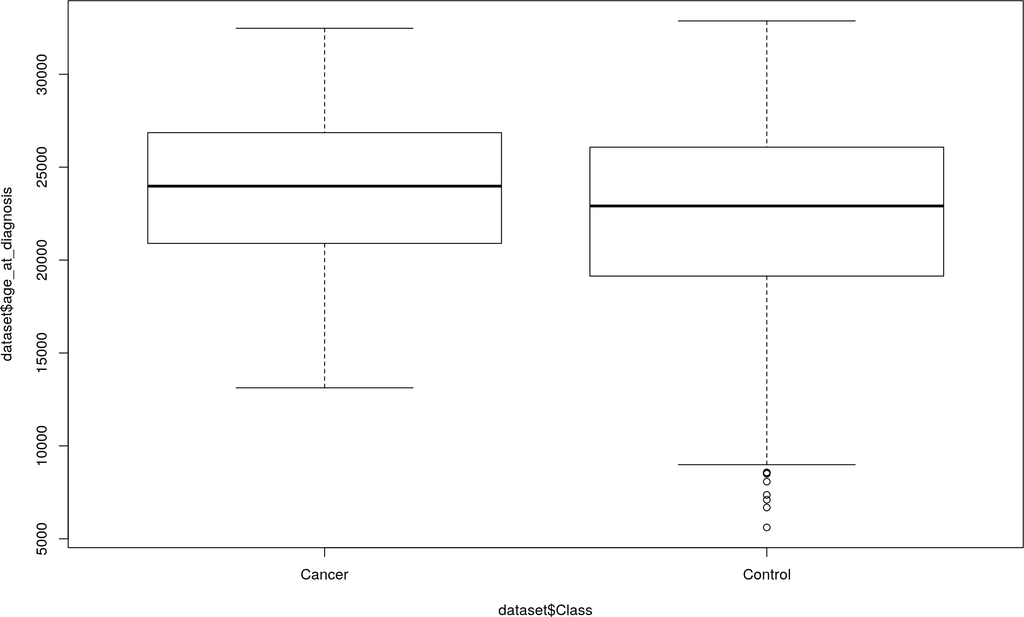

```r
boxplot(dataset$age_at_diagnosis ~ dataset$Class)
```

```r
t.test(dataset$age_at_diagnosis ~ dataset$Class)
```

```
#>
#>  Welch Two Sample t-test
#>
#> data:  dataset$age_at_diagnosis by dataset$Class
#> t = 3.88, df = 360.55, p-value = 0.0001242
#> alternative hypothesis: true difference in means is not equal to 0
#> 95 percent confidence interval:
#>   693.0905 2117.7294
#> sample estimates:
#>  mean in group Case mean in group Control
#>              23782.23              22376.82
```

```r
OmicSelector_table(table(dataset$gender.x, dataset$Class))
```

|  | Case | Control |
| --- | --- | --- |
| female | 80 | 334 |
| male | 98 | 325 |

```r
chisq.test(dataset$gender.x, dataset$Class)
```

```
#>
#>  Pearson's Chi-squared test with Yates' continuity correction
#>
#> data:  dataset$gender.x and dataset$Class
#> X-squared = 1.6241, df = 1, p-value = 0.2025
```

There is a stistically significant difference in age between classess. The gender was not associated with class. In order to increase feature selection performance, we will try to balance the sets by performing propensity score matching.

```r
old_dataset = dataset  # backup
dataset = dataset[grepl("Adenocarcinomas", dataset$disease_type), ]
match_by = c("age_at_diagnosis", "gender.x")
tempdane = dplyr::select(dataset, match_by)
tempdane$Class = ifelse(dataset$Class == "Case", TRUE, FALSE)
suppressMessages(library(mice))
suppressMessages(library(MatchIt))
temp1 = mice(tempdane, m = 1)
temp2 = temp1$data
temp3 = mice::complete(temp1)
temp3 = temp3[complete.cases(temp3), ]
tempform = OmicSelector_create_formula(match_by)
mod_match <- matchit(tempform, data = temp3)
newdata = match.data(mod_match)
dataset = dataset[as.numeric(rownames(newdata)), ]
```

Let’s check if there is any imbalance in the new, transformed dataset.

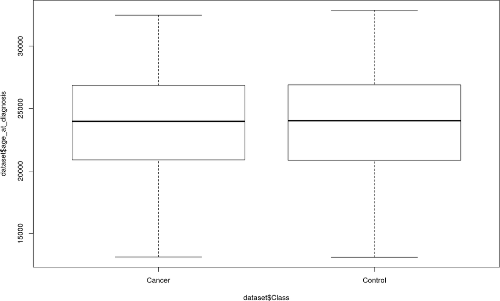

```r
boxplot(dataset$age_at_diagnosis ~ dataset$Class)
```

```r
t.test(dataset$age_at_diagnosis ~ dataset$Class)
```

```
#>
#>  Welch Two Sample t-test
#>
#> data:  dataset$age_at_diagnosis by dataset$Class
#> t = 0.090876, df = 351.63, p-value = 0.9276
#> alternative hypothesis: true difference in means is not equal to 0
#> 95 percent confidence interval:
#>  -827.5374  907.7172
#> sample estimates:
#>  mean in group Case mean in group Control
#>              23782.23              23742.14
```

```r
OmicSelector_table(table(dataset$gender.x, dataset$Class))
```

|  | Case | Control |
| --- | --- | --- |
| female | 80 | 79 |
| male | 98 | 99 |

```r
chisq.test(dataset$gender.x, dataset$Class)
```

```
#>
#>  Pearson's Chi-squared test with Yates' continuity correction
#>
#> data:  dataset$gender.x and dataset$Class
#> X-squared = 0, df = 1, p-value = 1
```

```r
fwrite(dataset, "balanced_dataset.csv.gz")
```

There are no significant differences in age or gender composition between classes now. We can proceed to standard filtering, log-transormation and TPM-normalization.

However, first, in order to stay consistent between different datasets, we need to standardise microRNA names. `OmicSelector_correct_miRNA_names()` unify the miRNA names between different versions of miRbase.

```r
dataset = OmicSelector_correct_miRNA_names(dataset)  # Correct miRNA names based on the aliases. Useful when analyzing old datasets - to keep the results coherent with current knowledge.
danex = dplyr::select(dataset, starts_with("hsa"))  # Create data.frame or matrix with miRNA counts with miRNAs in columns and cases in rows.
metadane = dplyr::select(dataset, -starts_with("hsa"))  # Metadata with 'Class' variables.
OmicSelector_table(table(metadane$Class))  # Let's be sure that 'Class' variable is correct and contains only 'Case' and 'Control' cases.
```

| Var1 | Freq |
| --- | --- |
| Case | 178 |
| Control | 178 |

```r
ttpm = OmicSelector_counts_to_log10tpm(danex, metadane, ids = metadane$sample, filtr = T, filtr_minimalcounts = 100, filtr_howmany = 1/3)  # We will leave only the miRNAs which apeared with at least 100 counts in 1/3 of cases.
```

```
#>
#> DGEList unfiltered object with TPM was saved as TPM_DGEList.rds.
#> DGEList filtered object with TPM was saved as TPM_DGEList_filtered.rds.
#> (After filtering) miRNAs left: 166 | filtered out: 2418.
#> Returned data are log10(TPM).
```

You might have noticed, that we have filtered out microRNAs not having at least 100 counts in 1/3 of samples. It was done to ensure that microRNAs selected as features for classifier (possibly used in clinic) would be detectable in other, cheaper methods, such as qPCR. After filtering there are 166 miRNAs left.

In the next step we will devide the dataset into training, testing and validation datasets. We strongly belive that hold-out validation is the most redundant validation method and although OmicSelector supports cross-validation, the hold-out validation is set by default in most cases. Thus, the rest of the analysis is dependent on existance of 3 seperate datasets:

- Training dataset (`mixed_train.csv`): By default 60%, used for differential expression, feature selection and model training.
- Testing dataset (`mixed_test.csv`): By default 20%, used for hyperparameter selection (in `holdout=T` mode)and for performance assessment.
- Validation dataset (`mixed_valid.csv`): By default 20%, used only for performance assessment.

The best signature (best set of miRNAs for diagnostic test) can be selected based on all 3 datasets, 2 datasets or only validation set. The process of best signature selection will be discussed below.

The split can be prepared manually by user (the pipeline expects to find `mixed_*.csv` files in working directory) or in a convinient way using `OmicSelector_prepare_split()`. Let’s do it now.

```r
mixed = OmicSelector_prepare_split(metadane = metadane, ttpm = ttpm, train_proc = 0.6)
```

```
#>
#> Saved 3 sets as csv in working directory. Retruned mixed dataset.
```

Let’s see a split summary.

```r
mixed = fread("mixed.csv")
OmicSelector_table(table(mixed$Class, mixed$mix))
```

|  | test | train | valid |
| --- | --- | --- | --- |
| Case | 36 | 107 | 35 |
| Control | 36 | 107 | 35 |

```r
OmicSelector_table(cbind(mixed[1:10, c(100:105)], Class = mixed[1:10, "Class"]))
```

| hsa-miR-30c-5p | hsa-miR-30c-2-3p | hsa-miR-30d-5p | hsa-miR-139-5p | hsa-miR-10a-5p | hsa-miR-10b-5p | Class.Class |
| --- | --- | --- | --- | --- | --- | --- |
| 2.598949 | 1.514444 | 3.802908 | 1.555401 | 4.735516 | 4.298381 | Case |
| 2.391663 | 1.416540 | 3.656058 | 1.326116 | 4.615369 | 3.946954 | Case |
| 2.576255 | 1.566166 | 3.721311 | 1.220338 | 4.385001 | 3.998914 | Case |
| 2.260492 | 1.401010 | 3.539243 | 1.924365 | 3.945605 | 4.486228 | Case |
| 2.595315 | 1.562735 | 3.571441 | 1.721510 | 4.519249 | 4.126032 | Case |
| 2.632860 | 1.723000 | 3.708020 | 2.120359 | 4.875796 | 3.887056 | Case |
| 2.747742 | 2.016887 | 3.852090 | 1.533525 | 3.961177 | 3.642831 | Case |
| 3.037578 | 1.880192 | 3.960987 | 1.798007 | 4.675070 | 4.133894 | Case |
| 2.598933 | 1.291485 | 3.581714 | 1.413095 | 4.580566 | 3.960672 | Case |
| 2.829601 | 1.494520 | 3.589292 | 1.755581 | 4.687104 | 4.209582 | Case |

We can see that the dataset was devided in balanced way. Now we are ready to move to the analysis…

# 4 Basic exploratory analysis

In biomarker studies we relay on validation. We perform hold-out validation, so the signature selection has to be based on training dataset only. Including testing and validation dataset in the exploratory analysis could lead to bias (‘data leakage’). In the following section we show how to use our package to perform quick exploratory analysis of miRNA-seq data.

```r
dane = OmicSelector_load_datamix(use_smote_not_rose = T)  # load mixed_*.csv files
train = dane[[1]]
test = dane[[2]]
valid = dane[[3]]
train_smoted = dane[[4]]
trainx = dane[[5]]
trainx_smoted = dane[[6]]  # get the objects from list to make the code more readable.
```

`ks_load_datamix()` function loads the data created in preparation phase. It requires the output constructed by `OmicSelector_prepare_split()` function to be placed in working directory (‘wd’), thus files ‘mixed_train.csv’, ‘mixed_test.csv’ and ‘mixed_valid.csv’ have to exist in the directory. If you have split the data manually, there may be some imbalance of classes in train, test or validation datasets. If so, `OmicSelector_prepare_split()` perform balancing using:

1. ROSE (default): https://journal.r-project.org/archive/2014/RJ-2014-008/RJ-2014-008.pdf - by default we generate 10 * number of cases in orginal dataset.
2. SMOTE: https://arxiv.org/abs/1106.1813 - by defult we use ‘perc.under=100’ and ‘k=10’.

At the beging of the analysis we usually perform **principal component analysis** (PCA) to assess for any batch effect, possible outliers and get a general understanding of miRNA profile. The package can construct 2-dimentional biplot and 3-dimentional interactive scatterplot based on the computed components.

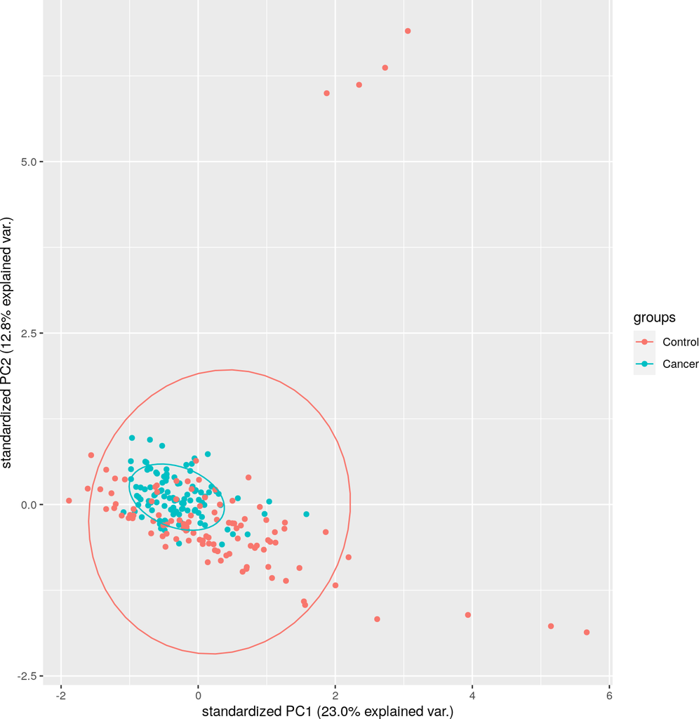

```r
pca = OmicSelector_PCA(trainx, train$Class)
pca
```

```r
pca3d = OmicSelector_PCA_3D(trainx, train$Class)
pca3d
```

[interactive chart not shown]

Now we can also correct the batch effect, if there is any. For example, you can use `OmicSelector_combat()` to do so. However, detailed demonstration is out of scope of this tutorial.

Usually, the next step in the exploratory analysis is to perform the differential expression analysis. Differential expression in our package is biomarker-discovery oriented, thus it uses t-test with the correction for multiple comparisons. The following table shows signifiantly differently expressed miRNAs after Benjamini-Hochberg correction.

```r
de = OmicSelector_differential_expression_ttest(trainx, train$Class)
sig_de = de %>% dplyr::filter(`p-value BH` <= 0.05) %>% dplyr::arrange(`p-value BH`)  # leave only significant after Benjamini-Hochberg procedure and sort by ascending p-value
OmicSelector_table(sig_de)
```

| miR | mean logtpm | median logtpm | SD logtpm | cancer mean | cancer median | cancer SD | control mean | control median | control SD | log10FC (subtr estim) | log10FC | log2FC | reversed_log10FC | reverse_log2FC | p-value | p-value Bonferroni | p-value Holm | -log10(p-value Bonferroni) | p-value BH |
| --- | --- | --- | --- | --- | --- | --- | --- | --- | --- | --- | --- | --- | --- | --- | --- | --- | --- | --- | --- |
| hsa.miR.21.5p | 5.081371 | 5.120977 | 0.5409456 | 5.473043 | 5.559281 | 0.3042087 | 4.689698 | 4.744446 | 0.4309906 | -0.7833450 | 0.7833450 | 2.6022157 | 0.7833450 | 2.6022157 | 0.0000000 | 0.0000000 | 0.0000000 | 32.2312221 | 0.0000000 |
| hsa.miR.30e.3p | 3.654915 | 3.620465 | 0.2922656 | 3.445100 | 3.469065 | 0.1835853 | 3.864731 | 3.891680 | 0.2215066 | 0.4196304 | -0.4196304 | -1.3939819 | -0.4196304 | -1.3939819 | 0.0000000 | 0.0000000 | 0.0000000 | 32.1422635 | 0.0000000 |
| hsa.miR.30a.3p | 3.861758 | 3.760500 | 0.5107622 | 3.494206 | 3.528067 | 0.2957390 | 4.229311 | 4.315264 | 0.4049904 | 0.7351047 | -0.7351047 | -2.4419651 | -0.7351047 | -2.4419651 | 0.0000000 | 0.0000000 | 0.0000000 | 31.8224321 | 0.0000000 |
| hsa.miR.30c.2.3p | 1.791478 | 1.685323 | 0.4609305 | 1.478041 | 1.473434 | 0.2548946 | 2.104915 | 2.062559 | 0.4044845 | 0.6268741 | -0.6268741 | -2.0824306 | -0.6268741 | -2.0824306 | 0.0000000 | 0.0000000 | 0.0000000 | 26.3237118 | 0.0000000 |
| hsa.miR.132.3p | 2.062941 | 2.061854 | 0.3206914 | 2.268277 | 2.222890 | 0.2453178 | 1.857606 | 1.842071 | 0.2476985 | -0.4106709 | 0.4106709 | 1.3642193 | 0.4106709 | 1.3642193 | 0.0000000 | 0.0000000 | 0.0000000 | 23.2892084 | 0.0000000 |
| hsa.miR.375.3p | 3.851381 | 4.088129 | 1.1312626 | 4.572062 | 4.593208 | 0.6167635 | 3.130699 | 3.420583 | 1.0689350 | -1.4413633 | 1.4413633 | 4.7881053 | 1.4413633 | 4.7881053 | 0.0000000 | 0.0000000 | 0.0000000 | 21.6930447 | 0.0000000 |
| hsa.miR.217.5p | 2.065790 | 1.932856 | 1.2184284 | 2.817892 | 2.596188 | 1.0079357 | 1.313689 | 1.247738 | 0.9084168 | -1.5042026 | 1.5042026 | 4.9968529 | 1.5042026 | 4.9968529 | 0.0000000 | 0.0000000 | 0.0000000 | 21.0021448 | 0.0000000 |
| hsa.miR.139.5p | 1.916157 | 1.919751 | 0.4638487 | 1.634747 | 1.558070 | 0.3573670 | 2.197567 | 2.204857 | 0.3804627 | 0.5628209 | -0.5628209 | -1.8696506 | -0.5628209 | -1.8696506 | 0.0000000 | 0.0000000 | 0.0000000 | 20.0671420 | 0.0000000 |
| hsa.miR.199a.5p | 3.034892 | 3.117770 | 0.3929526 | 3.267832 | 3.318017 | 0.2924584 | 2.801951 | 2.808411 | 0.3394148 | -0.4658802 | 0.4658802 | 1.5476204 | 0.4658802 | 1.5476204 | 0.0000000 | 0.0000000 | 0.0000000 | 18.7831163 | 0.0000000 |
| hsa.miR.338.3p | 2.743796 | 2.778247 | 0.4190933 | 2.991348 | 2.994550 | 0.3219668 | 2.496243 | 2.539407 | 0.3543332 | -0.4951049 | 0.4951049 | 1.6447027 | 0.4951049 | 1.6447027 | 0.0000000 | 0.0000000 | 0.0000000 | 18.6530266 | 0.0000000 |
| hsa.miR.199b.5p | 2.146095 | 2.358829 | 0.6145137 | 2.504540 | 2.573683 | 0.3567535 | 1.787650 | 1.799962 | 0.6100440 | -0.7168901 | 0.7168901 | 2.3814574 | 0.7168901 | 2.3814574 | 0.0000000 | 0.0000000 | 0.0000000 | 17.2507100 | 0.0000000 |
| hsa.miR.127.5p | 2.214220 | 2.327709 | 0.4803146 | 2.486170 | 2.478848 | 0.3020641 | 1.942270 | 1.939357 | 0.4722596 | -0.5438996 | 0.5438996 | 1.8067954 | 0.5438996 | 1.8067954 | 0.0000000 | 0.0000000 | 0.0000000 | 16.1634770 | 0.0000000 |
| hsa.miR.381.3p | 1.720930 | 1.791253 | 0.4579339 | 1.974984 | 1.949285 | 0.3353016 | 1.466877 | 1.476716 | 0.4226746 | -0.5081072 | 0.5081072 | 1.6878957 | 0.5081072 | 1.6878957 | 0.0000000 | 0.0000000 | 0.0000000 | 15.6751972 | 0.0000000 |
| hsa.miR.127.3p | 2.789656 | 2.829601 | 0.3874414 | 2.995898 | 3.006282 | 0.3147991 | 2.583413 | 2.568116 | 0.3415622 | -0.4124850 | 0.4124850 | 1.3702456 | 0.4124850 | 1.3702456 | 0.0000000 | 0.0000000 | 0.0000000 | 14.1819049 | 0.0000000 |
| hsa.miR.199a.3p | 3.431280 | 3.533249 | 0.3595668 | 3.620030 | 3.670480 | 0.2685999 | 3.242530 | 3.285480 | 0.3401837 | -0.3775004 | 0.3775004 | 1.2540293 | 0.3775004 | 1.2540293 | 0.0000000 | 0.0000000 | 0.0000000 | 13.5707699 | 0.0000000 |
| hsa.miR.181b.5p | 2.447025 | 2.523360 | 0.4131408 | 2.664941 | 2.705753 | 0.2848923 | 2.229109 | 2.205351 | 0.4073655 | -0.4358316 | 0.4358316 | 1.4478013 | 0.4358316 | 1.4478013 | 0.0000000 | 0.0000000 | 0.0000000 | 13.5990480 | 0.0000000 |
| hsa.miR.199b.3p | 3.430095 | 3.531945 | 0.3598114 | 3.619075 | 3.669630 | 0.2686093 | 3.241115 | 3.284615 | 0.3404382 | -0.3779599 | 0.3779599 | 1.2555557 | 0.3779599 | 1.2555557 | 0.0000000 | 0.0000000 | 0.0000000 | 13.5889555 | 0.0000000 |
| hsa.miR.194.5p | 3.119571 | 3.359054 | 0.8329947 | 3.562675 | 3.633752 | 0.4167141 | 2.676468 | 2.410622 | 0.9078933 | -0.8862067 | 0.8862067 | 2.9439150 | 0.8862067 | 2.9439150 | 0.0000000 | 0.0000000 | 0.0000000 | 13.2390851 | 0.0000000 |
| hsa.miR.134.5p | 2.366486 | 2.433393 | 0.4088244 | 2.572458 | 2.557931 | 0.2993653 | 2.160514 | 2.115254 | 0.4007277 | -0.4119434 | 0.4119434 | 1.3684465 | 0.4119434 | 1.3684465 | 0.0000000 | 0.0000000 | 0.0000000 | 12.1552043 | 0.0000000 |
| hsa.miR.30a.5p | 4.429837 | 4.356060 | 0.4519742 | 4.199892 | 4.226049 | 0.2683567 | 4.659782 | 4.685628 | 0.4813796 | 0.4598896 | -0.4598896 | -1.5277200 | -0.4598896 | -1.5277200 | 0.0000000 | 0.0000000 | 0.0000000 | 12.1052493 | 0.0000000 |
| hsa.miR.200a.5p | 2.480123 | 2.527551 | 0.5262405 | 2.744628 | 2.777438 | 0.3622178 | 2.215619 | 2.330898 | 0.5329388 | -0.5290086 | 0.5290086 | 1.7573286 | 0.5290086 | 1.7573286 | 0.0000000 | 0.0000000 | 0.0000000 | 11.9837197 | 0.0000000 |
| hsa.miR.136.5p | 1.426048 | 1.539528 | 0.5852494 | 1.722033 | 1.713813 | 0.2950712 | 1.130063 | 1.259715 | 0.6514071 | -0.5919692 | 0.5919692 | 1.9664791 | 0.5919692 | 1.9664791 | 0.0000000 | 0.0000000 | 0.0000000 | 11.6576372 | 0.0000000 |
| hsa.miR.192.5p | 3.474000 | 3.723466 | 0.8856187 | 3.920081 | 3.942126 | 0.4108526 | 3.027920 | 2.831424 | 1.0027511 | -0.8921615 | 0.8921615 | 2.9636965 | 0.8921615 | 2.9636965 | 0.0000000 | 0.0000000 | 0.0000000 | 11.4242384 | 0.0000000 |
| hsa.miR.451a | 2.540774 | 2.525599 | 0.6339915 | 2.233131 | 2.192706 | 0.4710976 | 2.848417 | 2.906464 | 0.6282318 | 0.6152860 | -0.6152860 | -2.0439357 | -0.6152860 | -2.0439357 | 0.0000000 | 0.0000000 | 0.0000000 | 11.0384525 | 0.0000000 |
| hsa.miR.200a.3p | 2.330223 | 2.419049 | 0.6863313 | 2.660594 | 2.674894 | 0.3970887 | 1.999851 | 2.171325 | 0.7539997 | -0.6607432 | 0.6607432 | 2.1949415 | 0.6607432 | 2.1949415 | 0.0000000 | 0.0000000 | 0.0000000 | 10.4637303 | 0.0000000 |
| hsa.miR.141.3p | 2.470222 | 2.587047 | 0.6758787 | 2.787653 | 2.835787 | 0.4142754 | 2.152790 | 2.366831 | 0.7368061 | -0.6348621 | 0.6348621 | 2.1089664 | 0.6348621 | 2.1089664 | 0.0000000 | 0.0000000 | 0.0000000 | 9.8966505 | 0.0000000 |
| hsa.miR.181c.3p | 1.549848 | 1.598609 | 0.3058360 | 1.691125 | 1.690791 | 0.2009568 | 1.408572 | 1.397065 | 0.3275293 | -0.2825529 | 0.2825529 | 0.9386203 | 0.2825529 | 0.9386203 | 0.0000000 | 0.0000000 | 0.0000000 | 9.5661290 | 0.0000000 |
| hsa.miR.30d.5p | 3.824938 | 3.786939 | 0.2585958 | 3.705810 | 3.708020 | 0.1763818 | 3.944065 | 3.950384 | 0.2731545 | 0.2382549 | -0.2382549 | -0.7914657 | -0.2382549 | -0.7914657 | 0.0000000 | 0.0000000 | 0.0000000 | 9.5425303 | 0.0000000 |
| hsa.miR.200b.3p | 2.716967 | 2.769036 | 0.5121158 | 2.949316 | 3.014389 | 0.3627291 | 2.484618 | 2.625241 | 0.5351976 | -0.4646977 | 0.4646977 | 1.5436922 | 0.4646977 | 1.5436922 | 0.0000000 | 0.0000000 | 0.0000000 | 9.2128238 | 0.0000000 |
| hsa.miR.708.3p | 1.553047 | 1.799718 | 0.7046857 | 1.878493 | 1.937453 | 0.3169286 | 1.227601 | 1.186108 | 0.8267867 | -0.6508920 | 0.6508920 | 2.1622164 | 0.6508920 | 2.1622164 | 0.0000000 | 0.0000000 | 0.0000000 | 9.1585590 | 0.0000000 |

[output cut: 85 more lines]

Let’s visualize the results of differential expression using heatmap and vulcano plot.

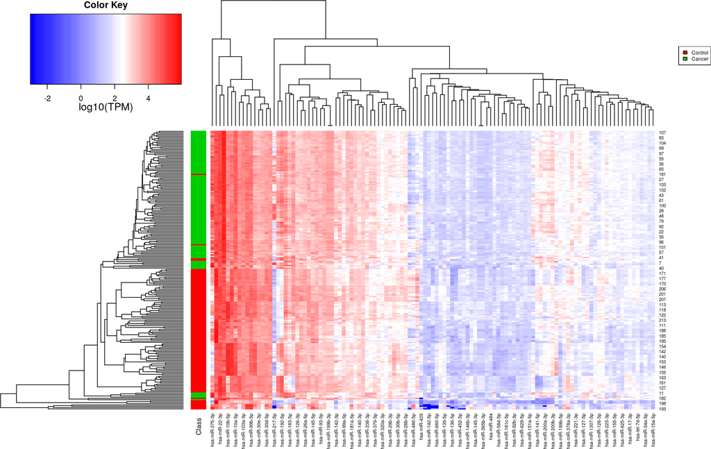

```r
OmicSelector_heatmap(x = dplyr::select(trainx, sig_de$miR), rlab = data.frame(Class = train$Class), zscore = F, margins = c(10, 10))
```

Z-scoring the values before clustering and plotting will help us to gain more insight.

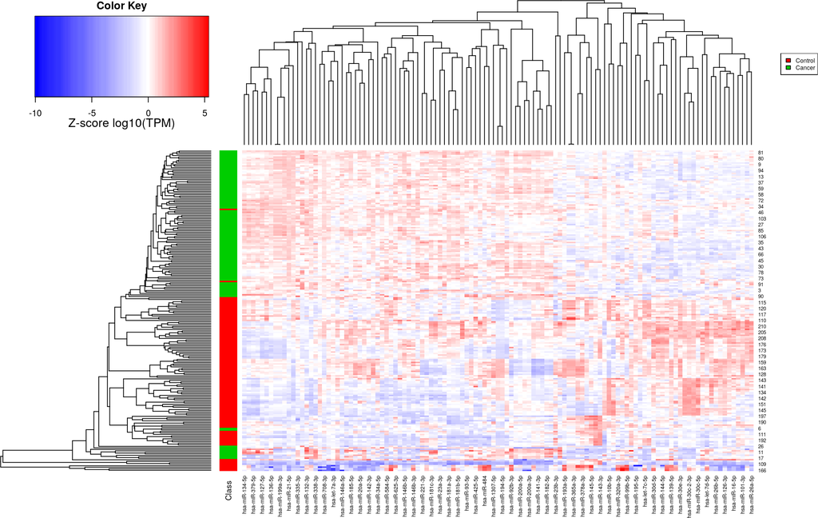

```r
OmicSelector_heatmap(x = dplyr::select(trainx, sig_de$miR), rlab = data.frame(Class = train$Class), zscore = T, margins = c(10, 10))
```

We will also create a vulcano plot and label top 10 most significant miRNAs:

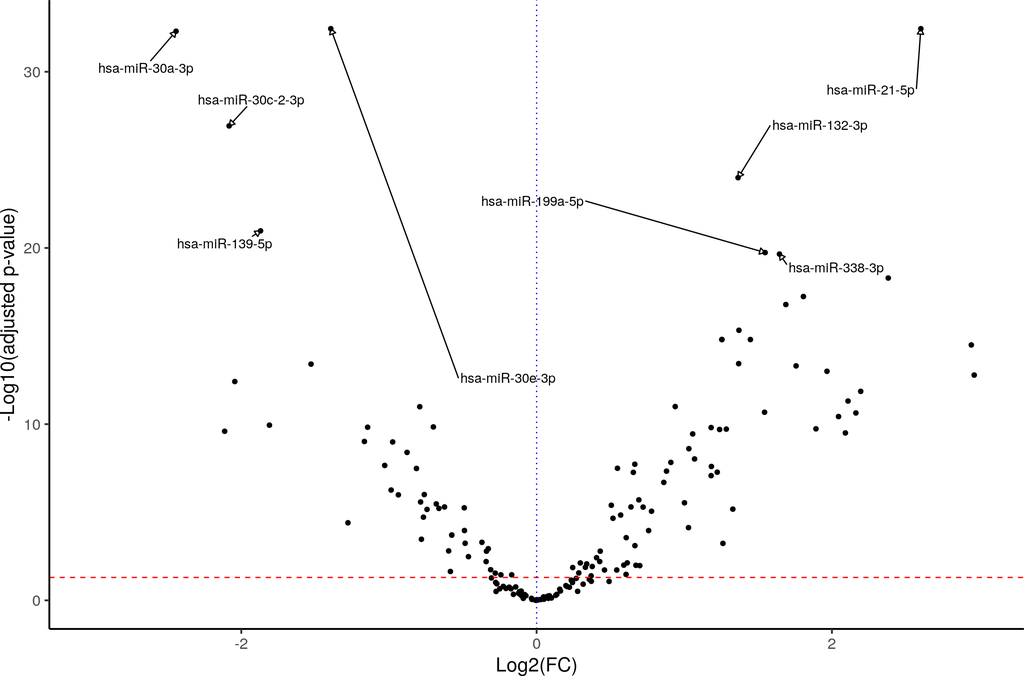

```r
OmicSelector_vulcano_plot(selected_miRNAs = de$miR, DE = de, only_label = sig_de$miR[1:10])
```

We may also what to check the consistency of differential expression between datasets:

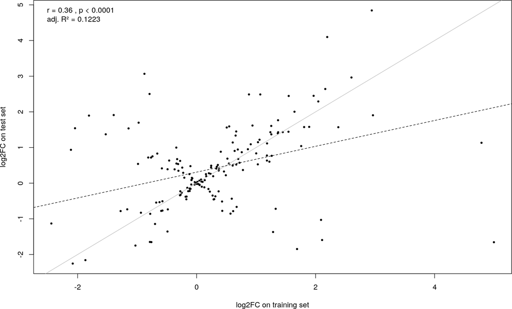

```r
de_test = OmicSelector_differential_expression_ttest(dplyr::select(test, starts_with("hsa")), test$Class)
de_valid = OmicSelector_differential_expression_ttest(dplyr::select(valid, starts_with("hsa")), valid$Class)
OmicSelector_correlation_plot(de$log2FC, de_test$log2FC, "log2FC on training set", "log2FC on test set", "", yx = T)
```

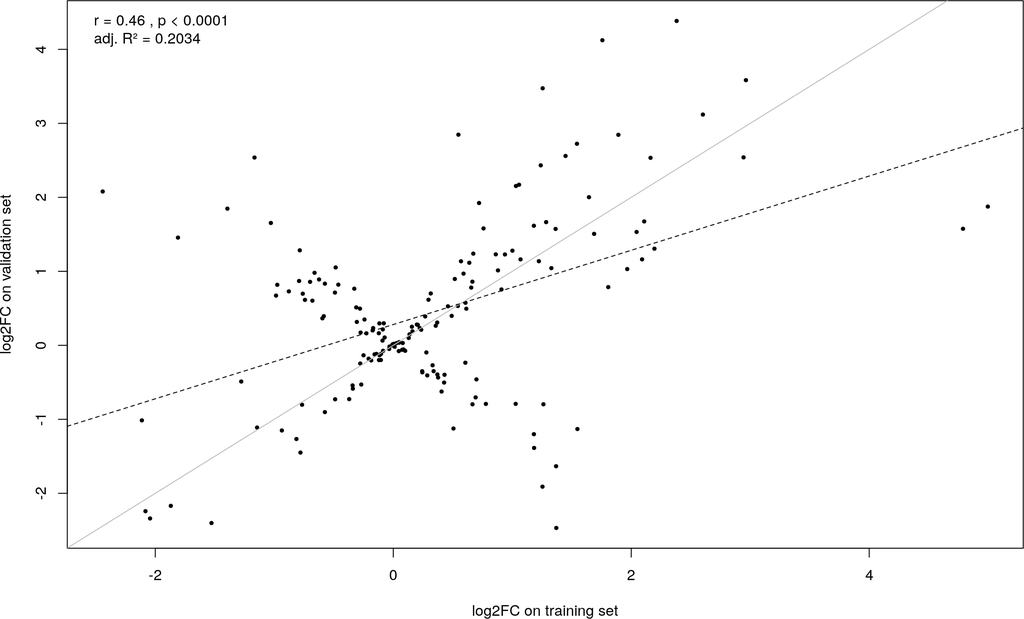

```r
OmicSelector_correlation_plot(de$log2FC, de_valid$log2FC, "log2FC on training set", "log2FC on validation set", "", yx = T)
```

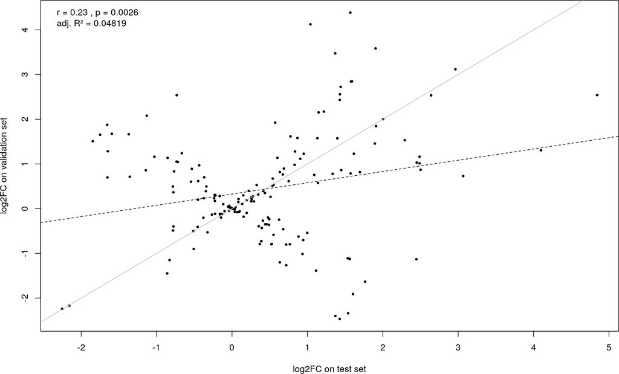

```r
OmicSelector_correlation_plot(de_test$log2FC, de_valid$log2FC, "log2FC on test set", "log2FC on validation set", "", yx = T)
```

# 5 miRNA selection

The main feature of this package is the shotgun-like feature selection evaluation of possible miRNA signatures of biological processes. The function can be applied in a straightforward way, e.g.:

```r
selected_features = OmicSelector_OmicSelector(wd = getwd(), m = 1:10, max_iterations = 1, stamp = "tutorial")  # we just run only first 10 methods for the sake of speed.
```

But, for largers projects we suggest using the following wrapper wich will perform the feature selection in parallel, significantly reducing computational time. We do not recommend using more than 5 threads, beacuse some of the methods inhereditly use multicore processing:

```r
readLines("Tutorial_OmicSelector.R") %>% paste0(collapse = "\n") %>% cat
```

```
#> #options(warn = -1)
#> suppressMessages(library(foreach))
#> suppressMessages(library(doParallel))
#> suppressMessages(library(parallel))
#> suppressMessages(library(doParallel))
#>
#> m = 1:56 # which methods to check?
#>
#> cl <- makePSOCKcluster(useXDR = TRUE, 5) # We do not recommend using more than 5 threads, beacuse some of the methods inhereditly use multicore processing.
#> doParallel:: registerDoParallel(cl)
#> iterations = length(m)
#> pb <- txtProgressBar(max = iterations, style = 3)
#> progress <- function(n) setTxtProgressBar(pb, n)
#> opts <- list(progress = progress)
#> foreach(i = m, .options.snow = opts) %dopar%
#> {
#>   suppressMessages(library(OmicSelector))
#>   # setwd("/OmicSelector/OmicSelector/vignettes") # change it you to your working directory
#>   OmicSelector_OmicSelector(m = i, max_iterations = 1, stamp = "tutorial", debug = F, # we set debug to false (to make the package smaller), you may also want to change stamp to something meaningful, max_iterations was set to 1 to recude the computational time.. in real life scenarios it is reson…
#>                   prefer_no_features = 11, # Few methods are filter rather than wrapper methods, thus requires the maximum number of maximum features.
#>                   conda_path = "/opt/conda/bin/conda", # Methods line WxNet requires usage of python. In setup script we create conda enviorment. Providing conda_path makes it easier to activate env. We prefer this apporach over use_condaenv.
#>                   timeout = 600) # We don't want to wait eternity in this tutorial, just 10 minutes. Timeout is useful for complicated methods. Depending on your CPU 2 days may be reasonable for larger projects. Note that some methods cannot be controled with timeout parameter.
#> }
#>
#> stopCluster(cl)
#> #options(warn = 0)
```

If you are using our enviorment to learn this package you can tweak and run this code in the interactive notebook. Click here.

A few notes about what is does:

- This function iterates though available methods which are described by `m` parameter. The aim of this function is to perform feature selection using multiple methods and to create formulas for benchmarking.
- It loads the data from working directory. The output is mainly put in files in the working directory. Log and temporary files are placed in a created `temp` subfolder.

Files created for each method (e.g. for `stamp=tutorial` and `m=1`):

- `formulastutorial-1.RDS` - main result file containing the final formula (final set of miRNAs selected by this method).
- `time1-formula.RDS` - time taken to compute the results
- `tutorial1featureselection.log` - log file of the process
- (optional) `all1-tutorial.rdata` - all variables created during feature selection (created if `debug=T`).

Pearls about the methods:

- `Sig` = miRNAs with p-value <0.05 after BH correction (DE using t-test)
- `Fcsig` = `sig` + absolute log2FC filter (included if abs. log2FC>1)
- `Cfs` = Correlation-based Feature Selection for Machine Learning (more: https://www.cs.waikato.ac.nz/~mhall/thesis.pdf)
- `Classloop` = Classification using different classification algorithms (classifiers) with the embedded feature selection and using the different schemes for the performance validation (more: https://rdrr.io/cran/Biocomb/man/classifier.loop.html)
- `Fcfs` = CFS algorithm with forward search (https://rdrr.io/cran/Biocomb/man/select.forward.Corr.html)
- `MDL` methods = minimal description length (MDL) discretization algorithm with different a method of feature ranking or feature selection (AUC, SU, CorrSF) (more: https://rdrr.io/cran/Biocomb/man/select.process.html)
- `bounceR` = genetic algorithm with componentwise boosting (more: https://www.statworx.com/ch/blog/automated-feature-selection-using-bouncer/)
- `RandomForestRFE` = recursive feature elimination using random forest with resampling to assess the performance. (more: https://topepo.github.io/caret/recursive-feature-elimination.html#resampling-and-external-validation)
- `GeneticAlgorithmRF` (more: https://topepo.github.io/caret/feature-selection-using-genetic-algorithms.html)
- `SimulatedAnnealing` = makes small random changes (i.e. perturbations) to an initial candidate solution (more: https://topepo.github.io/caret/feature-selection-using-simulated-annealing.html)
- `Boruta` (more: https://www.jstatsoft.org/article/view/v036i11/v36i11.pdf)
- `spFSR` = simultaneous perturbation stochastic approximation (SPSA-FSR) (more: https://arxiv.org/abs/1804.05589)
- `varSelRF` = using the out-of-bag error as minimization criterion, carry out variable elimination from random forest, by successively eliminating the least important variables (with importance as returned from random forest). (more: https://www.ncbi.nlm.nih.gov/pubmed/16398926)
- `WxNet` = a neural network-based feature selection algorithm for transcriptomic data (more: https://www.ncbi.nlm.nih.gov/pmc/articles/PMC6642261/)
- `Step` = backward stepwise method of feature selection based on logistic regression (GLM, family = binomial) using AIC criteria (stepAIC) and functions from My.stepwise package (https://cran.r-project.org/web/packages/My.stepwise/index.html)

Notes about methods:

The `OmicSelector` functions saves all output files to `temp/` directory. As users may want to run multiple selection methods in different configurations, we do not recommend using the return of this function in the following steps. Instead, we provide `OmicSelector_merge_formulas()` which conviniently summerizes the results of feature selection. We can do:

```r
selected_sets_of_miRNAs = OmicSelector_merge_formulas(max_miRNAs = 11)  # we filter out sets with more than 11 miRNAs.
selected_sets_of_miRNAs_with_own = OmicSelector_merge_formulas(max_miRNAs = 11, add = list(my_own_signature = c("hsa.miR.192.5p", "hsa.let.7g.5p", "hsa.let.7a.5p",
    "hsa.let.7d.5p", "hsa.miR.194.5p", "hsa.miR.98.5p", "hsa.let.7f.5p", "hsa.miR.26b.5p")))  # you can also add your own signature (for example selected from literature)
```

Note that:

- Two files are created in working directory: (1) `featureselection_formulas_all.RDS` - contains the formulas for all selection methods, (2) `featureselection_formulas_final.RDS` - contains methods that selected smaller or equal number of microRNAs than specified in `max_miRNA` parameter, as well as `fcsig` and `cfs_sig`.
- The results of `fcsig` and `cfs_sig` methods are always retained in the final `formulas` set (ignoring `max_miRNA` parameter) - they are commonly used as benchmark comparator for the final set of miRNAs. Those sets can be manually removed (if needed) from final selection.
- Readable tables are written in corresponding `*.csv` files.

Let’s analyze the process of feature selection:

```r
all_sets = readRDS("featureselection_formulas_all.RDS")
length(all_sets)  # How many feature selection methods completed in time?
```

```
#> [1] 23
```

```r
final_sets = readRDS("featureselection_formulas_final.RDS")
length(final_sets)  # How many feature selection methods completed in time and fulfilled max_miRNA criteria? (remember about fcsig and cfs_sig)
```

```
#> [1] 14
```

```r
featureselection_formulas_final = fread("featureselection_formulas_final.csv")
OmicSelector_table(featureselection_formulas_final)  # show information about selected formulas
```

| name | formula | ile_miRNA |
| --- | --- | --- |
| cfs_sig | Class ~ hsa.miR.21.5p + hsa.miR.30e.3p + hsa.miR.30a.3p + hsa.miR.30c.2.3p + hsa.miR.132.3p + hsa.miR.375.3p + hsa.miR.217.5p + hsa.miR.338.3p + hsa.miR.199b.5p + hsa.miR.381.3p + hsa.miR.199a.3p + hs… | 34 |
| fcsig | Class ~ hsa.miR.21.5p + hsa.miR.30e.3p + hsa.miR.30a.3p + hsa.miR.30c.2.3p + hsa.miR.132.3p + hsa.miR.375.3p + hsa.miR.217.5p + hsa.miR.139.5p + hsa.miR.199a.5p + hsa.miR.338.3p + hsa.miR.199b.5p + hs… | 50 |
| my_own_signature | Class ~ hsa.miR.192.5p + hsa.let.7g.5p + hsa.let.7a.5p + hsa.let.7d.5p + hsa.miR.194.5p + hsa.miR.98.5p + hsa.let.7f.5p + hsa.miR.26b.5p | 0 |
| sigtop | Class ~ hsa.miR.21.5p + hsa.miR.30e.3p + hsa.miR.30a.3p + hsa.miR.30c.2.3p + hsa.miR.132.3p + hsa.miR.375.3p + hsa.miR.217.5p + hsa.miR.139.5p + hsa.miR.199a.5p + hsa.miR.338.3p + hsa.miR.199b.5p | 11 |
| sigtopBonf | Class ~ hsa.miR.21.5p + hsa.miR.30e.3p + hsa.miR.30a.3p + hsa.miR.30c.2.3p + hsa.miR.132.3p + hsa.miR.375.3p + hsa.miR.217.5p + hsa.miR.139.5p + hsa.miR.199a.5p + hsa.miR.338.3p + hsa.miR.199b.5p | 11 |
| sigtopHolm | Class ~ hsa.miR.21.5p + hsa.miR.30e.3p + hsa.miR.30a.3p + hsa.miR.30c.2.3p + hsa.miR.132.3p + hsa.miR.375.3p + hsa.miR.217.5p + hsa.miR.139.5p + hsa.miR.199a.5p + hsa.miR.338.3p + hsa.miR.199b.5p | 11 |
| topFC | Class ~ hsa.miR.217.5p + hsa.miR.375.3p + hsa.miR.192.5p + hsa.miR.194.5p + hsa.miR.21.5p + hsa.miR.30a.3p + hsa.miR.199b.5p + hsa.miR.200a.3p + hsa.miR.708.3p + hsa.miR.144.5p + hsa.miR.141.3p | 11 |
| sigtopSMOTE | Class ~ hsa.let.7c.5p + hsa.miR.16.5p + hsa.miR.20a.5p + hsa.miR.21.5p + hsa.miR.21.3p + hsa.miR.22.3p + hsa.miR.23a.3p + hsa.miR.26a.5p + hsa.miR.26b.5p + hsa.miR.27a.3p + hsa.miR.29a.3p | 11 |
| sigtopBonfSMOTE | Class ~ hsa.let.7c.5p + hsa.miR.16.5p + hsa.miR.20a.5p + hsa.miR.21.5p + hsa.miR.21.3p + hsa.miR.22.3p + hsa.miR.23a.3p + hsa.miR.26a.5p + hsa.miR.26b.5p + hsa.miR.27a.3p + hsa.miR.29a.3p | 11 |
| sigtopHolmSMOTE | Class ~ hsa.let.7c.5p + hsa.miR.16.5p + hsa.miR.20a.5p + hsa.miR.21.5p + hsa.miR.21.3p + hsa.miR.22.3p + hsa.miR.23a.3p + hsa.miR.26a.5p + hsa.miR.26b.5p + hsa.miR.27a.3p + hsa.miR.29a.3p | 11 |
| topFCSMOTE | Class ~ hsa.miR.217.5p + hsa.miR.375.3p + hsa.miR.192.5p + hsa.miR.194.5p + hsa.miR.21.5p + hsa.miR.30a.3p + hsa.miR.199b.5p + hsa.miR.144.5p + hsa.miR.30c.2.3p + hsa.miR.210.3p + hsa.miR.200a.3p | 11 |
| cfsSMOTE | Class ~ hsa.miR.21.5p + hsa.miR.30a.3p + hsa.miR.30e.3p + hsa.miR.375.3p + hsa.miR.708.3p | 5 |
| cfsSMOTE_sig | Class ~ hsa.miR.21.5p + hsa.miR.30e.3p + hsa.miR.30a.3p + hsa.miR.375.3p + hsa.miR.708.3p | 5 |
| fcfsSMOTE | Class ~ hsa.miR.21.5p + hsa.miR.30a.3p + hsa.miR.708.3p + hsa.miR.375.3p + hsa.miR.30e.3p | 5 |

Note that `my_own_signture` has `0` miRNAs according to the table. This trick is done to make sure that signatures added manually will not be filtered out based on `max_miRNA` parameter.

Now, we will summarize number of microRNAs selected by methods implemented in `OmicSelector_OmicSelector` by creating histogram and calculating some descriptive statistics.

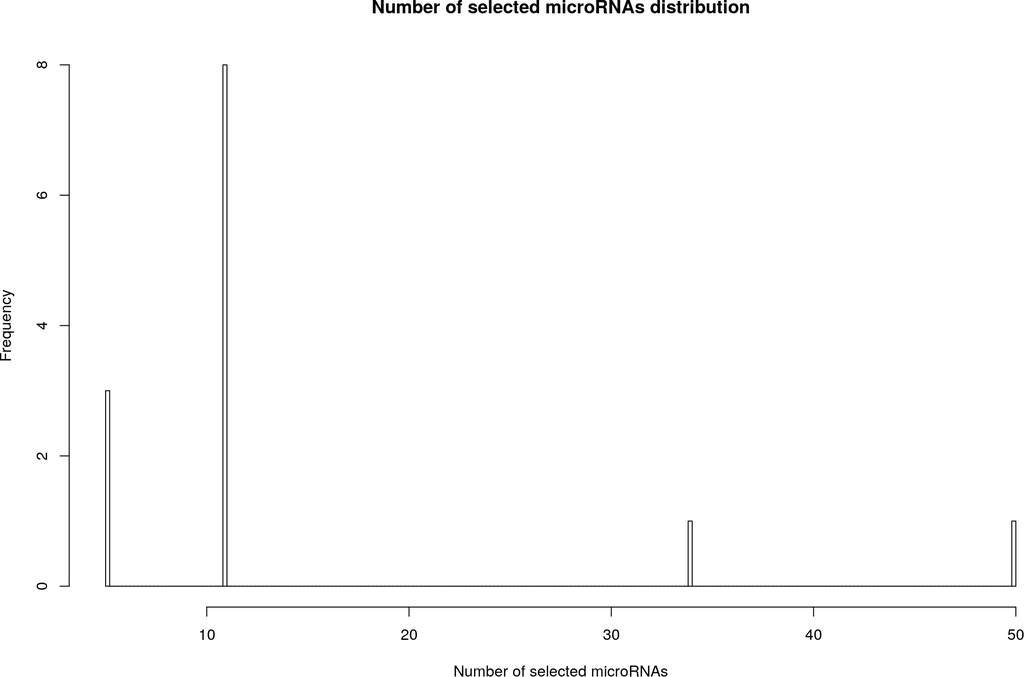

```r
hist(featureselection_formulas_final$ile_miRNA[-which(featureselection_formulas_final$ile_miRNA == 0)], breaks = ncol(train), main = "Number of selected microRNAs distribution",
    xlab = "Number of selected microRNAs")  # Histogram showing how many miRNAs were selected in final set.
```

```r
psych::describe(featureselection_formulas_final$ile_miRNA[-which(featureselection_formulas_final$ile_miRNA == 0)])  # Descriptive statistics of how many features where selected in the final set.
```

```
#>    vars  n  mean    sd median trimmed mad min max range skew kurtosis   se
#> X1    1 13 14.38 12.94     11      12   0   5  50    45 1.77     1.89 3.59
```

# 6 Benchmarking

In the next step of looking for the best microRNA signature, we perform benchmarking. This tests all the signatures using different classifier architectures. Here is the example of benchmark with default parameters:

```r
readLines("Tutorial_benchmark.R") %>% paste0(collapse = "\n") %>% cat
```

[output not shown]

If you are using our enviorment to learn this package you can tweak and run this code in the interactive notebook. Click here.

Just for rendering this tutorial we will use a very simple benchmark using only logistic regression and conditional trees.

```r
OmicSelector_benchmark(search_iters = 5, # 5 random hyperparameter sets will be checked; 5 is set here for speed purposes.. for real projects use more, like 5000...
            algorithms = c("ctree"), # just add ctree, note that logistic regression (glm) is always included
            output_file = paste0("benchmark.csv")) # the main output
```

```
#>              method SMOTE
#> 1           cfs_sig    No
#> 2             fcsig    No
#> 3  my_own_signature    No
#> 4            sigtop    No
#> 5        sigtopBonf    No
#> 6        sigtopHolm    No
#> 7             topFC    No
#> 8       sigtopSMOTE   Yes
#> 9   sigtopBonfSMOTE   Yes
#> 10  sigtopHolmSMOTE   Yes
#> 11       topFCSMOTE   Yes
#> 12         cfsSMOTE   Yes
#> 13     cfsSMOTE_sig   Yes
#> 14        fcfsSMOTE   Yes
```

[output cut: 150 more lines]

As benchmarking is done, the main result file is saved in file specified in `output_file` parameter. It contains the performance metrics of signatures satisfying initial criteria (e.g. `max_miRNA`) across different methods of modelling. Let’s take a quick look:

```r
OmicSelector_table(fread("benchmark.csv"))
```

| V1 | method | SMOTE | miRy | glm_modelname | glm_train_ROCAUC | glm_train_ROCAUC_lower95CI | glm_train_ROCAUC_upper95CI | glm_train_Accuracy | glm_train_Sensitivity | glm_train_Specificity | glm_test_Accuracy | glm_test_Sensitivity | glm_test_Specificity | glm_valid_Accuracy | glm_valid_Sensitivity | glm_valid_Specificity | ctree_modelname | ctree_train_ROCAUC | ctree_train_ROCAUC_lower95CI | ctree_train_ROCAUC_upper95CI | ctree_train_Accuracy | ctree_train_Sensitivity | ctree_train_Specificity | ctree_test_Accuracy | ctree_test_Sensitivity | ctree_test_Specificity | ctree_valid_Accuracy | ctree_valid_Sensitivity | ctree_valid_Specificity |
| --- | --- | --- | --- | --- | --- | --- | --- | --- | --- | --- | --- | --- | --- | --- | --- | --- | --- | --- | --- | --- | --- | --- | --- | --- | --- | --- | --- | --- | --- |
| 1 | cfs_sig | No | Class ~ hsa.miR.21.5p + hsa.miR.30e.3p + hsa.miR.30a.3p + hsa.miR.30c.2.3p + hsa.miR.132.3p + hsa.miR.375.3p + hsa.miR.217.5p + hsa.miR.338.3p + hsa.miR.199b.5p + hsa.miR.381.3p + hsa.miR.199a.3p + hs… | 1589408746 | 1.0000000 | 1.0000000 | 1.0000000 | 1.0000000 | 1.0000000 | 1.0000000 | 0.8888889 | 0.9166667 | 0.8611111 | 1.0000000 | 1.0000000 | 1.0000000 | 1589409024 | 0.9768539 | 0.9567499 | 0.9969579 | 0.9485981 | 0.9813084 | 0.9158879 | 0.9305556 | 1.0000000 | 0.8611111 | 0.9571429 | 1.0000000 | 0.9142857 |
| 2 | fcsig | No | Class ~ hsa.miR.21.5p + hsa.miR.30e.3p + hsa.miR.30a.3p + hsa.miR.30c.2.3p + hsa.miR.132.3p + hsa.miR.375.3p + hsa.miR.217.5p + hsa.miR.139.5p + hsa.miR.199a.5p + hsa.miR.338.3p + hsa.miR.199b.5p + hs… | 1589408757 | 1.0000000 | 1.0000000 | 1.0000000 | 1.0000000 | 1.0000000 | 1.0000000 | 0.9166667 | 0.9166667 | 0.9166667 | 0.9571429 | 1.0000000 | 0.9142857 | 1589409035 | 0.9943663 | 0.9892504 | 0.9994823 | 0.9579439 | 0.9345794 | 0.9813084 | 0.9166667 | 0.9444444 | 0.8888889 | 0.9571429 | 0.9714286 | 0.9428571 |
| 3 | my_own_signature | No | Class ~ hsa.miR.192.5p + hsa.let.7g.5p + hsa.let.7a.5p + hsa.let.7d.5p + hsa.miR.194.5p + hsa.miR.98.5p + hsa.let.7f.5p + hsa.miR.26b.5p | 1589408768 | 0.9239235 | 0.8901386 | 0.9577083 | 0.8317757 | 0.8504673 | 0.8130841 | 0.8472222 | 0.8055556 | 0.8888889 | 0.8857143 | 0.8857143 | 0.8857143 | 1589409047 | 0.9753254 | 0.9605664 | 0.9900843 | 0.8971963 | 0.8317757 | 0.9626168 | 0.7916667 | 0.6944444 | 0.8888889 | 0.8714286 | 0.8000000 | 0.9428571 |
| 4 | sigtop | No | Class ~ hsa.miR.21.5p + hsa.miR.30e.3p + hsa.miR.30a.3p + hsa.miR.30c.2.3p + hsa.miR.132.3p + hsa.miR.375.3p + hsa.miR.217.5p + hsa.miR.139.5p + hsa.miR.199a.5p + hsa.miR.338.3p + hsa.miR.199b.5p | 1589408779 | 0.9961569 | 0.9902191 | 1.0000000 | 0.9859813 | 1.0000000 | 0.9719626 | 0.9444444 | 1.0000000 | 0.8888889 | 0.9714286 | 1.0000000 | 0.9428571 | 1589409058 | 0.9905232 | 0.9794706 | 1.0000000 | 0.9579439 | 0.9345794 | 0.9813084 | 0.9166667 | 0.9444444 | 0.8888889 | 0.9571429 | 0.9714286 | 0.9428571 |
| 5 | sigtopBonf | No | Class ~ hsa.miR.21.5p + hsa.miR.30e.3p + hsa.miR.30a.3p + hsa.miR.30c.2.3p + hsa.miR.132.3p + hsa.miR.375.3p + hsa.miR.217.5p + hsa.miR.139.5p + hsa.miR.199a.5p + hsa.miR.338.3p + hsa.miR.199b.5p | 1589408789 | 0.9961569 | 0.9902191 | 1.0000000 | 0.9859813 | 1.0000000 | 0.9719626 | 0.9444444 | 1.0000000 | 0.8888889 | 0.9714286 | 1.0000000 | 0.9428571 | 1589409070 | 0.9905232 | 0.9794706 | 1.0000000 | 0.9579439 | 0.9345794 | 0.9813084 | 0.9166667 | 0.9444444 | 0.8888889 | 0.9571429 | 0.9714286 | 0.9428571 |
| 6 | sigtopHolm | No | Class ~ hsa.miR.21.5p + hsa.miR.30e.3p + hsa.miR.30a.3p + hsa.miR.30c.2.3p + hsa.miR.132.3p + hsa.miR.375.3p + hsa.miR.217.5p + hsa.miR.139.5p + hsa.miR.199a.5p + hsa.miR.338.3p + hsa.miR.199b.5p | 1589408800 | 0.9961569 | 0.9902191 | 1.0000000 | 0.9859813 | 1.0000000 | 0.9719626 | 0.9444444 | 1.0000000 | 0.8888889 | 0.9714286 | 1.0000000 | 0.9428571 | 1589409082 | 0.9905232 | 0.9794706 | 1.0000000 | 0.9579439 | 0.9345794 | 0.9813084 | 0.9166667 | 0.9444444 | 0.8888889 | 0.9571429 | 0.9714286 | 0.9428571 |
| 7 | topFC | No | Class ~ hsa.miR.217.5p + hsa.miR.375.3p + hsa.miR.192.5p + hsa.miR.194.5p + hsa.miR.21.5p + hsa.miR.30a.3p + hsa.miR.199b.5p + hsa.miR.200a.3p + hsa.miR.708.3p + hsa.miR.144.5p + hsa.miR.141.3p | 1589408810 | 0.9939733 | 0.9856621 | 1.0000000 | 0.9813084 | 0.9906542 | 0.9719626 | 0.9444444 | 1.0000000 | 0.8888889 | 0.9857143 | 1.0000000 | 0.9714286 | 1589409093 | 0.9944537 | 0.9893380 | 0.9995693 | 0.9579439 | 0.9906542 | 0.9252336 | 0.9305556 | 0.9722222 | 0.8888889 | 0.9714286 | 1.0000000 | 0.9428571 |
| 8 | sigtopSMOTE | Yes | Class ~ hsa.let.7c.5p + hsa.miR.16.5p + hsa.miR.20a.5p + hsa.miR.21.5p + hsa.miR.21.3p + hsa.miR.22.3p + hsa.miR.23a.3p + hsa.miR.26a.5p + hsa.miR.26b.5p + hsa.miR.27a.3p + hsa.miR.29a.3p | 1589408820 | 0.9954188 | 0.9948865 | 0.9959511 | 0.9748454 | 0.9731776 | 0.9764967 | 0.8888889 | 0.9166667 | 0.8611111 | 0.9714286 | 1.0000000 | 0.9428571 | 1589409105 | 0.9999357 | 0.9998459 | 1.0000000 | 0.9993955 | 1.0000000 | 0.9987971 | 0.8611111 | 0.7500000 | 0.9722222 | 0.9428571 | 0.8857143 | 1.0000000 |
| 9 | sigtopBonfSMOTE | Yes | Class ~ hsa.let.7c.5p + hsa.miR.16.5p + hsa.miR.20a.5p + hsa.miR.21.5p + hsa.miR.21.3p + hsa.miR.22.3p + hsa.miR.23a.3p + hsa.miR.26a.5p + hsa.miR.26b.5p + hsa.miR.27a.3p + hsa.miR.29a.3p | 1589408845 | 0.9954188 | 0.9948865 | 0.9959511 | 0.9748454 | 0.9731776 | 0.9764967 | 0.8888889 | 0.9166667 | 0.8611111 | 0.9714286 | 1.0000000 | 0.9428571 | 1589409129 | 0.9999357 | 0.9998459 | 1.0000000 | 0.9993955 | 1.0000000 | 0.9987971 | 0.8611111 | 0.7500000 | 0.9722222 | 0.9428571 | 0.8857143 | 1.0000000 |
| 10 | sigtopHolmSMOTE | Yes | Class ~ hsa.let.7c.5p + hsa.miR.16.5p + hsa.miR.20a.5p + hsa.miR.21.5p + hsa.miR.21.3p + hsa.miR.22.3p + hsa.miR.23a.3p + hsa.miR.26a.5p + hsa.miR.26b.5p + hsa.miR.27a.3p + hsa.miR.29a.3p | 1589408870 | 0.9954188 | 0.9948865 | 0.9959511 | 0.9748454 | 0.9731776 | 0.9764967 | 0.8888889 | 0.9166667 | 0.8611111 | 0.9714286 | 1.0000000 | 0.9428571 | 1589409151 | 0.9999357 | 0.9998459 | 1.0000000 | 0.9993955 | 1.0000000 | 0.9987971 | 0.8611111 | 0.7500000 | 0.9722222 | 0.9428571 | 0.8857143 | 1.0000000 |
| 11 | topFCSMOTE | Yes | Class ~ hsa.miR.217.5p + hsa.miR.375.3p + hsa.miR.192.5p + hsa.miR.194.5p + hsa.miR.21.5p + hsa.miR.30a.3p + hsa.miR.199b.5p + hsa.miR.144.5p + hsa.miR.30c.2.3p + hsa.miR.210.3p + hsa.miR.200a.3p | 1589408897 | 0.9977293 | 0.9973001 | 0.9981585 | 0.9912587 | 1.0000000 | 0.9826039 | 0.9444444 | 1.0000000 | 0.8888889 | 0.9857143 | 1.0000000 | 0.9714286 | 1589409176 | 0.9999653 | 0.9999020 | 1.0000000 | 0.9996745 | 1.0000000 | 0.9993523 | 0.9444444 | 0.8888889 | 1.0000000 | 0.9571429 | 0.9142857 | 1.0000000 |
| 12 | cfsSMOTE | Yes | Class ~ hsa.miR.21.5p + hsa.miR.30a.3p + hsa.miR.30e.3p + hsa.miR.375.3p + hsa.miR.708.3p | 1589408921 | 0.9971039 | 0.9964570 | 0.9977508 | 0.9839587 | 0.9811215 | 0.9867678 | 0.9305556 | 0.9722222 | 0.8888889 | 0.9857143 | 1.0000000 | 0.9714286 | 1589409197 | 0.9995422 | 0.9993638 | 0.9997205 | 0.9981866 | 1.0000000 | 0.9963912 | 0.9444444 | 0.9444444 | 0.9444444 | 0.9571429 | 0.9428571 | 0.9714286 |
| 13 | cfsSMOTE_sig | Yes | Class ~ hsa.miR.21.5p + hsa.miR.30e.3p + hsa.miR.30a.3p + hsa.miR.375.3p + hsa.miR.708.3p | 1589408941 | 0.9971039 | 0.9964570 | 0.9977508 | 0.9839587 | 0.9811215 | 0.9867678 | 0.9305556 | 0.9722222 | 0.8888889 | 0.9857143 | 1.0000000 | 0.9714286 | 1589409218 | 0.9995422 | 0.9993638 | 0.9997205 | 0.9981866 | 1.0000000 | 0.9963912 | 0.9444444 | 0.9444444 | 0.9444444 | 0.9571429 | 0.9428571 | 0.9714286 |
| 14 | fcfsSMOTE | Yes | Class ~ hsa.miR.21.5p + hsa.miR.30a.3p + hsa.miR.708.3p + hsa.miR.375.3p + hsa.miR.30e.3p | 1589408964 | 0.9971039 | 0.9964570 | 0.9977508 | 0.9839587 | 0.9811215 | 0.9867678 | 0.9305556 | 0.9722222 | 0.8888889 | 0.9857143 | 1.0000000 | 0.9714286 | 1589409238 | 0.9995422 | 0.9993638 | 0.9997205 | 0.9981866 | 1.0000000 | 0.9963912 | 0.9444444 | 0.9444444 | 0.9444444 | 0.9571429 | 0.9428571 | 0.9714286 |

Description of columns:

- `method` - accronym for method
- `SMOTE` - if balancing using SMOTE or ROSE was used in training dataset.
- `miRy` - formula used (miRNAs selected).
- `*_modelname` - the name of `.RDS` file placed in `models/` directory, containing the `caret` final model that can be used for prediction of new cases. This allows reproducibility of the results. For example `glm_` prefix is set according to the method, `glm` = logistic regression.
- `*_train_ROCAUC` - area under the ROC curve (AUC ROC) on training dataset, indicating general potential of the model.
- `*_train_ROCAUC_lower95CI` - lower boundery of 95% confidence interval for AUC ROC.
- `*_train_ROCAUC_upper95CI` - upper boundery of 95% confidence interval for AUC ROC.
- `*_train_Accuracy` - accuracy on training set.
- `*_train_Sensitivity` - sensitivity on training set.
- `*_train_Specificity` - sensitivity on training set.

By this logic every parameter is also calculated from testing (`_test_`) and validation (`_valid_`) set. If the method generated a probability, a default cutoff is used for all of the predictions.

Let’s see the general performance (accuracy) of methods in the benchmark:

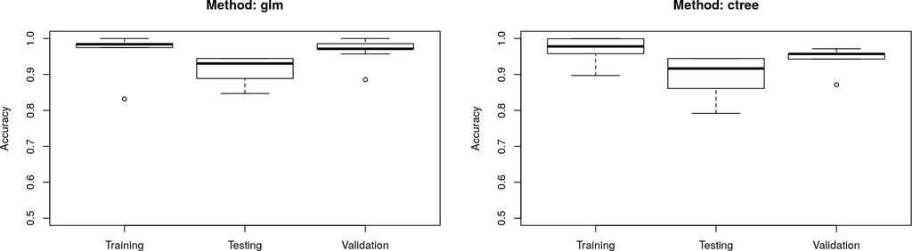

```r
metody = OmicSelector_get_benchmark_methods("benchmark.csv")  # gets the methods used in benchmark
par(mfrow = c(2, 2))
for (i in 1:length(metody)) {
    temp = OmicSelector_get_benchmark("benchmark.csv")  # loads benchmark
    temp2 = dplyr::select(temp, starts_with(paste0(metody[i], "_")))
    boxplot(temp[, paste0(metody[i], "_train_Accuracy")], temp[, paste0(metody[i], "_test_Accuracy")], temp[, paste0(metody[i], "_valid_Accuracy")], main = paste0("Method: ",
        metody[i]), names = c("Training", "Testing", "Validation"), ylab = "Accuracy", ylim = c(0.5, 1))
    tempids = c(match(paste0(metody[i], "_train_Accuracy"), colnames(temp)), match(paste0(metody[i], "_test_Accuracy"), colnames(temp)), match(paste0(metody[i],
        "_valid_Accuracy"), colnames(temp)))
}
par(mfrow = c(1, 1))
```

With `OmicSelector` package, the final optimal feature signature can be selected in 3 ways:

**1. Picking the signture which achived the best accuracy in training, testing and validation:** (metaindex = mean of all 3 accuracy metrics)

```r
acc1 = OmicSelector_best_signature_proposals(benchmark_csv = "benchmark.csv", without_train = F)  # generates the benchmark sorted by metaindex
best_signatures = acc1[1:3, ]  # get top 3 methods
OmicSelector_table(best_signatures[, c("metaindex", "method", "miRy")])
```

| metaindex | method | miRy |
| --- | --- | --- |
| 0.9704465 | topFCSMOTE | Class ~ hsa.miR.217.5p + hsa.miR.375.3p + hsa.miR.192.5p + hsa.miR.194.5p + hsa.miR.21.5p + hsa.miR.30a.3p + hsa.miR.199b.5p + hsa.miR.144.5p + hsa.miR.30c.2.3p + hsa.miR.210.3p + hsa.miR.200a.3p |
| 0.9666671 | cfsSMOTE | Class ~ hsa.miR.21.5p + hsa.miR.30a.3p + hsa.miR.30e.3p + hsa.miR.375.3p + hsa.miR.708.3p |
| 0.9666671 | cfsSMOTE_sig | Class ~ hsa.miR.21.5p + hsa.miR.30e.3p + hsa.miR.30a.3p + hsa.miR.375.3p + hsa.miR.708.3p |

**2. Picking the signture which achived the best accuracy in testing and validation:** (metaindex = mean of 2 accuracy metrics)

```r
acc1 = OmicSelector_best_signature_proposals(benchmark_csv = "benchmark.csv", without_train = T)  # generates the benchmark sorted by metaindex
best_signatures = acc1[1:3, ]  # get top 3 methods
OmicSelector_table(best_signatures[, c("metaindex", "method", "miRy")])
```

[output not shown]

**3. The signture which achived the best sensitivity and specificity in validation:** (metaindex = mean of sensivitiy and specificity in validation dataset)

```r
acc = OmicSelector_best_signature_proposals_meta11(benchmark_csv = "benchmark.csv")  # generates the benchmark sorted by metaindex
best_signatures = acc[1:3, ]  # get top 3 methods
OmicSelector_table(best_signatures[, c("metaindex", "method", "miRy")])
```

| metaindex | method | miRy |
| --- | --- | --- |
| 0.9571429 | cfs_sig | Class ~ hsa.miR.21.5p + hsa.miR.30e.3p + hsa.miR.30a.3p + hsa.miR.30c.2.3p + hsa.miR.132.3p + hsa.miR.375.3p + hsa.miR.217.5p + hsa.miR.338.3p + hsa.miR.199b.5p + hsa.miR.381.3p + hsa.miR.199a.3p + hs… |
| 0.9571429 | topFC | Class ~ hsa.miR.217.5p + hsa.miR.375.3p + hsa.miR.192.5p + hsa.miR.194.5p + hsa.miR.21.5p + hsa.miR.30a.3p + hsa.miR.199b.5p + hsa.miR.200a.3p + hsa.miR.708.3p + hsa.miR.144.5p + hsa.miR.141.3p |
| 0.9428571 | topFCSMOTE | Class ~ hsa.miR.217.5p + hsa.miR.375.3p + hsa.miR.192.5p + hsa.miR.194.5p + hsa.miR.21.5p + hsa.miR.30a.3p + hsa.miR.199b.5p + hsa.miR.144.5p + hsa.miR.30c.2.3p + hsa.miR.210.3p + hsa.miR.200a.3p |

It is a good practice to assess learning performance for considered signatures across different classification methods. Here, we visualize the over/underfitting of selected methods by comparing accuracy score between testing and validation sets for 5 top scoring signatures across selection of model architectures.

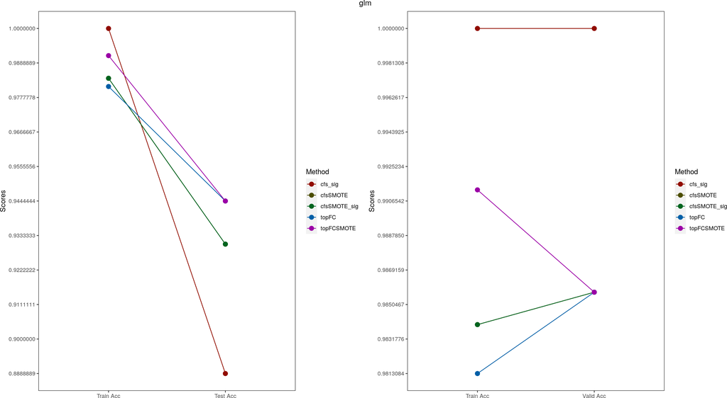

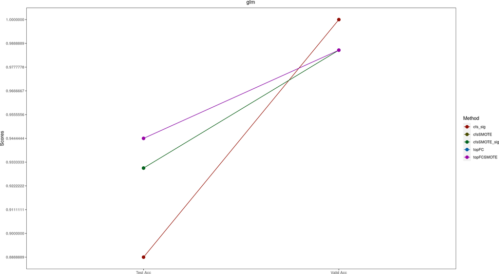

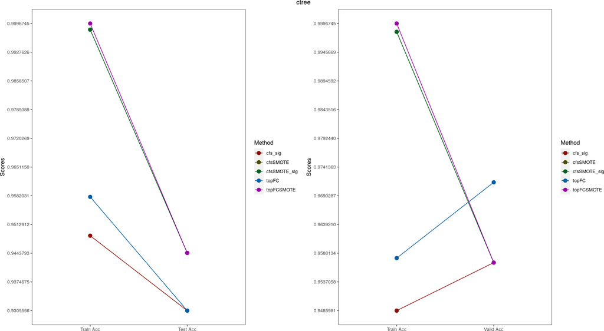

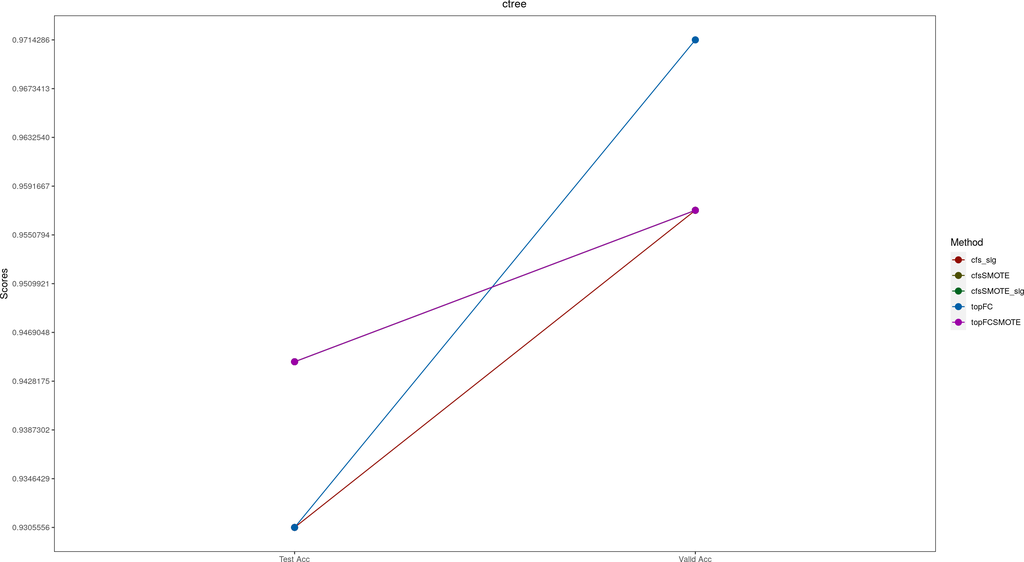

```r
for (i in 1:length(metody)) {
    suppressMessages(library(PairedData))
    suppressMessages(library(profileR))
    pd = paired(as.numeric(acc[1:5, paste0(metody[i], "_train_Accuracy")]), as.numeric(acc[1:5, paste0(metody[i], "_test_Accuracy")]))
    colnames(pd) = c("Train Acc", "Test Acc")
    plot2 = OmicSelector_profileplot(pd, Method.id = acc$method[1:5], standardize = F)
    pd = paired(as.numeric(acc[1:5, paste0(metody[i], "_train_Accuracy")]), as.numeric(acc[1:5, paste0(metody[i], "_valid_Accuracy")]))
    colnames(pd) = c("Train Acc", "Valid Acc")
    plot3 = OmicSelector_profileplot(pd, Method.id = acc$method[1:5], standardize = F)
    pd = paired(as.numeric(acc[1:5, paste0(metody[i], "_test_Accuracy")]), as.numeric(acc[1:5, paste0(metody[i], "_valid_Accuracy")]))
    colnames(pd) = c("Test Acc", "Valid Acc")
    plot4 = OmicSelector_profileplot(pd, Method.id = acc$method[1:5], standardize = F)



    require(gridExtra)
    grid.arrange(arrangeGrob(plot2, plot3, ncol = 2, nrow = 1, top = metody[i]))
    grid.arrange(arrangeGrob(plot4, ncol = 1, nrow = 1, top = metody[i]))
}
```

The relationship betweend accuracy on testing and validation sets can also be pictured as scatterplot:

```r
acc2 = acc[1:6, ]  # get top 6 methods
accmelt = melt(acc2, id.vars = "method") %>% filter(variable != "metaindex") %>% filter(variable != "miRy")
accmelt = cbind(accmelt, strsplit2(accmelt$variable, "_"))
acctest = accmelt$value[accmelt$`2` == "test"]
accvalid = accmelt$value[accmelt$`2` == "valid"]
accmeth = accmelt$method[accmelt$`2` == "test"]
unique(accmeth)
```

```
#> [1] "cfs_sig"      "topFC"        "topFCSMOTE"   "cfsSMOTE"     "cfsSMOTE_sig"
#> [6] "fcfsSMOTE"
```

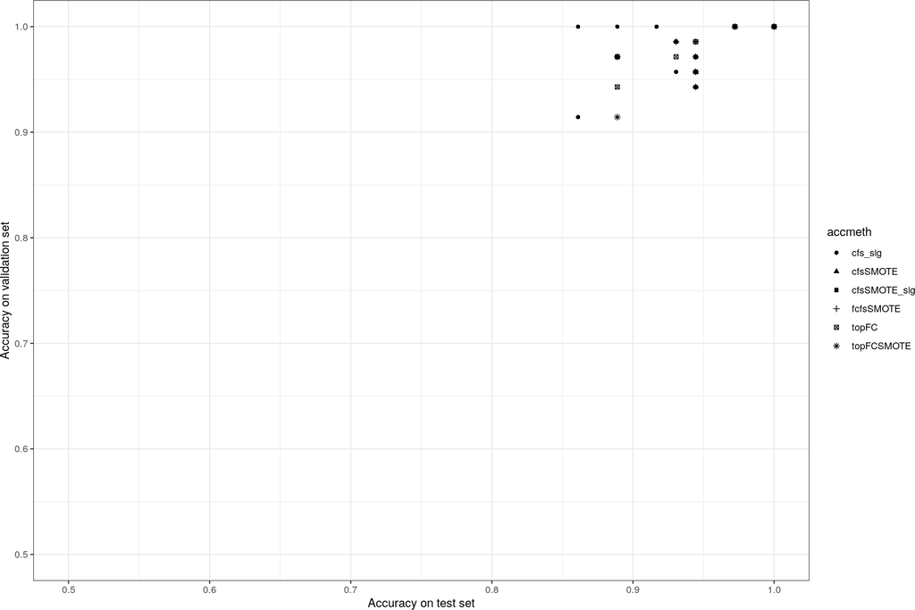

```r
plot5 = ggplot(, aes(x = as.numeric(acctest), y = as.numeric(accvalid), shape = accmeth)) + geom_point() + scale_x_continuous(name = "Accuracy on test set",
    limits = c(0.5, 1)) + scale_y_continuous(name = "Accuracy on validation set", limits = c(0.5, 1)) + theme_bw()
grid.arrange(arrangeGrob(plot5, ncol = 1, nrow = 1))
```

# 7 Best signture analysis

Suppose we decide to use sensitivity and specificity in validation set (e.g. in the model architectures we plan to use in our research) as decisive scoring metric for feature signature. The three best signatures may be:

```r
OmicSelector_table(best_signatures[1:3, 2:4])
```

| method | SMOTE | miRy |
| --- | --- | --- |
| cfs_sig | No | Class ~ hsa.miR.21.5p + hsa.miR.30e.3p + hsa.miR.30a.3p + hsa.miR.30c.2.3p + hsa.miR.132.3p + hsa.miR.375.3p + hsa.miR.217.5p + hsa.miR.338.3p + hsa.miR.199b.5p + hsa.miR.381.3p + hsa.miR.199a.3p + hs… |
| topFC | No | Class ~ hsa.miR.217.5p + hsa.miR.375.3p + hsa.miR.192.5p + hsa.miR.194.5p + hsa.miR.21.5p + hsa.miR.30a.3p + hsa.miR.199b.5p + hsa.miR.200a.3p + hsa.miR.708.3p + hsa.miR.144.5p + hsa.miR.141.3p |
| topFCSMOTE | Yes | Class ~ hsa.miR.217.5p + hsa.miR.375.3p + hsa.miR.192.5p + hsa.miR.194.5p + hsa.miR.21.5p + hsa.miR.30a.3p + hsa.miR.199b.5p + hsa.miR.144.5p + hsa.miR.30c.2.3p + hsa.miR.210.3p + hsa.miR.200a.3p |

To get the miRNAs from formula you can use `OmicSelector_get_features_from_benchmark`.

```r
selected_miRNAs = OmicSelector_get_features_from_benchmark(benchmark_csv = "benchmark.csv", best_signatures$method[1])  # for the best performing signature
gsub("\\.", "-", selected_miRNAs)  # R doesn't like hyphens, but we can introduce them easly
```

```
#>  [1] "hsa-miR-21-5p"    "hsa-miR-30e-3p"   "hsa-miR-30a-3p"   "hsa-miR-30c-2-3p"
#>  [5] "hsa-miR-132-3p"   "hsa-miR-375-3p"   "hsa-miR-217-5p"   "hsa-miR-338-3p"
#>  [9] "hsa-miR-199b-5p"  "hsa-miR-381-3p"   "hsa-miR-199a-3p"  "hsa-miR-194-5p"
#> [13] "hsa-miR-134-5p"   "hsa-miR-192-5p"   "hsa-miR-200a-3p"  "hsa-miR-181c-3p"
#> [17] "hsa-miR-29a-3p"   "hsa-miR-378a-3p"  "hsa-miR-144-5p"   "hsa-miR-335-3p"
#> [21] "hsa-miR-126-5p"   "hsa-let-7c-5p"    "hsa-miR-378a-5p"  "hsa-miR-181c-5p"
#> [25] "hsa-miR-126-3p"   "hsa-miR-185-5p"   "hsa-miR-29c-3p"   "hsa-miR-151a-5p"
#> [29] "hsa-miR-92b-3p"   "hsa-miR-10b-5p"   "hsa-miR-195-5p"   "hsa-miR-101-3p"
#> [33] "hsa-miR-484"      "hsa-miR-28-3p"
```

As a double check, we can inspect the differential expression of miRNAs constituating selected signature:

```r
best_de = OmicSelector_best_signature_de(selected_miRNAs)
OmicSelector_table(best_de)
```

|  | miR | log2FC | p-value BH |
| --- | --- | --- | --- |
| 1 | hsa.miR.21.5p | 2.6022157 | 0.0000000 |
| 2 | hsa.miR.30e.3p | -1.3939819 | 0.0000000 |
| 3 | hsa.miR.30a.3p | -2.4419651 | 0.0000000 |
| 4 | hsa.miR.30c.2.3p | -2.0824306 | 0.0000000 |
| 5 | hsa.miR.132.3p | 1.3642193 | 0.0000000 |
| 6 | hsa.miR.375.3p | 4.7881053 | 0.0000000 |
| 7 | hsa.miR.217.5p | 4.9968529 | 0.0000000 |
| 10 | hsa.miR.338.3p | 1.6447027 | 0.0000000 |
| 11 | hsa.miR.199b.5p | 2.3814574 | 0.0000000 |
| 13 | hsa.miR.381.3p | 1.6878957 | 0.0000000 |
| 15 | hsa.miR.199a.3p | 1.2540293 | 0.0000000 |
| 18 | hsa.miR.194.5p | 2.9439150 | 0.0000000 |
| 19 | hsa.miR.134.5p | 1.3684465 | 0.0000000 |
| 23 | hsa.miR.192.5p | 2.9636965 | 0.0000000 |
| 25 | hsa.miR.200a.3p | 2.1949415 | 0.0000000 |
| 27 | hsa.miR.181c.3p | 0.9386203 | 0.0000000 |
| 33 | hsa.miR.29a.3p | -0.6991346 | 0.0000000 |
| 34 | hsa.miR.378a.3p | -1.1444252 | 0.0000000 |
| 39 | hsa.miR.144.5p | -2.1127868 | 0.0000000 |
| 41 | hsa.miR.335.3p | 1.0571023 | 0.0000000 |
| 42 | hsa.miR.126.5p | -1.1663511 | 0.0000000 |
| 45 | hsa.let.7c.5p | -0.8775535 | 0.0000000 |
| 49 | hsa.miR.378a.5p | -1.0287466 | 0.0000000 |
| 57 | hsa.miR.181c.5p | 0.8614935 | 0.0000002 |
| 58 | hsa.miR.126.3p | -0.9851906 | 0.0000005 |
| 61 | hsa.miR.185.5p | 0.6922687 | 0.0000020 |
| 62 | hsa.miR.29c.3p | -0.7856959 | 0.0000026 |
| 65 | hsa.miR.151a.5p | 0.5057800 | 0.0000040 |
| 73 | hsa.miR.92b.3p | 0.7783325 | 0.0000088 |
| 77 | hsa.miR.10b.5p | -1.2777969 | 0.0000396 |
| 84 | hsa.miR.195.5p | -0.7802161 | 0.0003412 |
| 90 | hsa.miR.101.3p | -0.5956161 | 0.0015624 |
| 106 | hsa.miR.484 | -0.3113168 | 0.0182773 |
| 113 | hsa.miR.28.3p | -0.2419443 | 0.0355939 |

Let’s visualize the performance of those methods using barplots:

```
#>
#>
#> ## cfs_sig
```

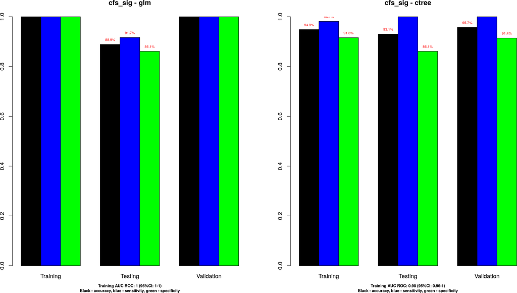

```
#>
#>
#> ## topFC
```

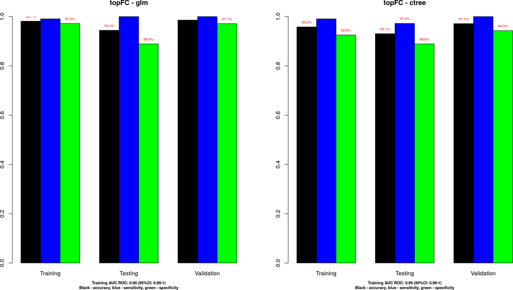

```
#>
#>
#> ## topFCSMOTE
```

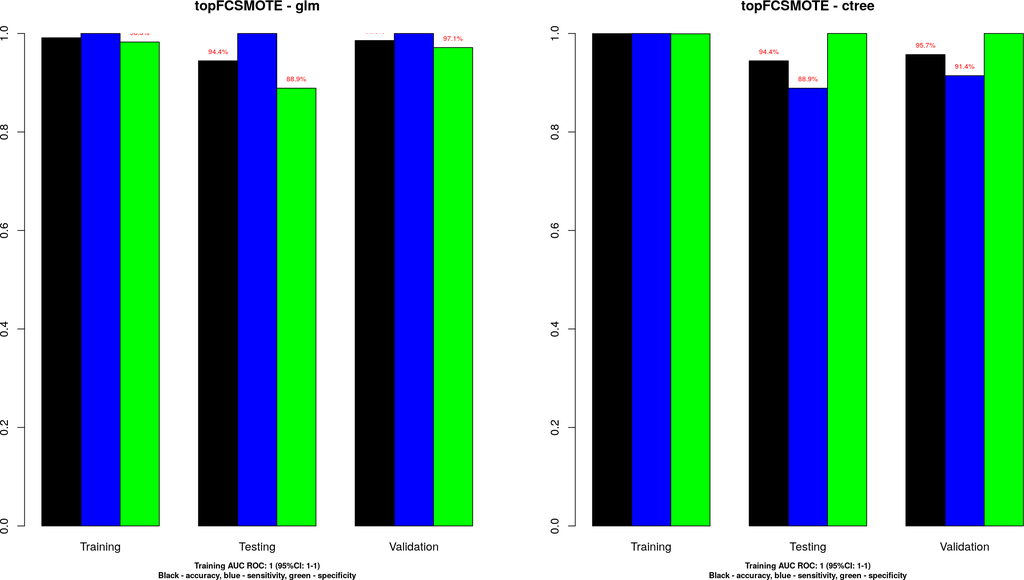

```r
for (i in 1:3) {
    cat(paste0("\n\n## ", acc$method[i], "\n\n"))
    par(mfrow = c(1, 2))
    acc = OmicSelector_best_signature_proposals_meta11("benchmark.csv")
    metody = OmicSelector_get_benchmark_methods("benchmark.csv")
    ktory_set = match(acc$method[i], OmicSelector_get_benchmark("benchmark.csv")$method)
    # do_ktorej_kolumny = which(colnames(acc) == 'metaindex') barplot(as.numeric(acc[i,1:do_ktorej_kolumny]))
    for (ii in 1:length(metody)) {

        temp = OmicSelector_get_benchmark("benchmark.csv") %>% dplyr::select(starts_with(paste0(metody[ii], "_t")), starts_with(paste0(metody[ii], "_v")))

        ROCtext = paste0("Training AUC ROC: ", round(temp[ktory_set, 1], 2), " (95%CI: ", round(temp[ktory_set, 2], 2), "-", round(temp[ktory_set, 3],
            2), ")")

        temp = temp[, -c(1:3)]
        temp2 = as.numeric(temp[ktory_set, ])
        temp3 = matrix(temp2, nrow = 3, byrow = T)
        colnames(temp3) = c("Accuracy", "Sensitivity", "Specificity")
        rownames(temp3) = c("Training", "Testing", "Validation")
        temp3 = t(temp3)

        plot1 = barplot(temp3, beside = T, ylim = c(0, 1), xlab = paste0(ROCtext, "\nBlack - accuracy, blue - sensitivity, green - specificity"), width = 0.85,
            col = c("black", "blue", "green"), legend = F, args.legend = list(x = "topright", bty = "n", inset = c(0, -0.25)), cex.lab = 0.7, main = paste0(acc$method[i],
                " - ", metody[ii]), font.lab = 2)
        ## Add text at top of bars
        text(x = plot1, y = as.numeric(temp3), label = paste0(round(as.numeric(temp[ktory_set, ]) * 100, 1), "%"), pos = 3, cex = 0.6, col = "red")
    }
    par(mfrow = c(1, 1))

}
```

Finally, we can assess the overlap of top 3 feature selection methods:

```r
overlap = OmicSelector_signature_overlap(acc$method[1:3], "benchmark.csv")
```

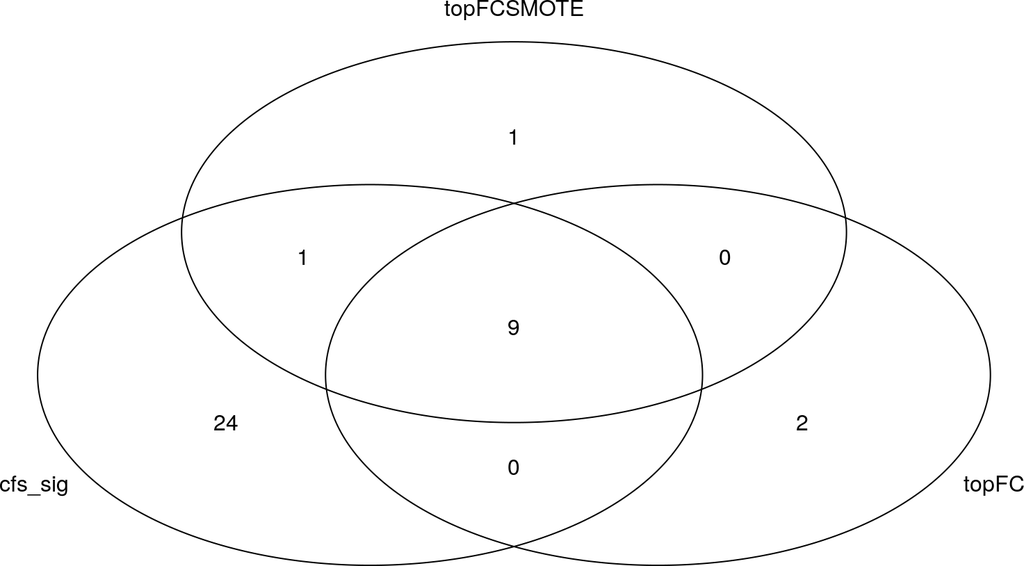

```r
attr(overlap, "intersections")[4]
```

```
#> $topFC
#> [1] "hsa.miR.708.3p" "hsa.miR.141.3p"
```

Let’s draw vulcano plot and mark the miRNAs selected in best signature:

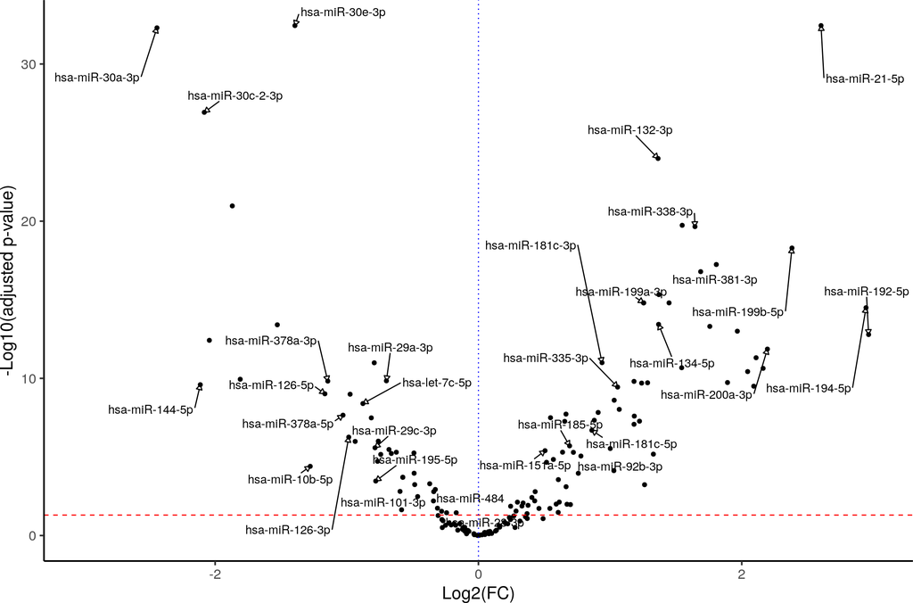

```r
OmicSelector_vulcano_plot(selected_miRNAs = de$miR, DE = de, only_label = selected_miRNAs)
```

Let’s draw heatmap for selected miRNAs in whole dataset (training, testing and validation set).

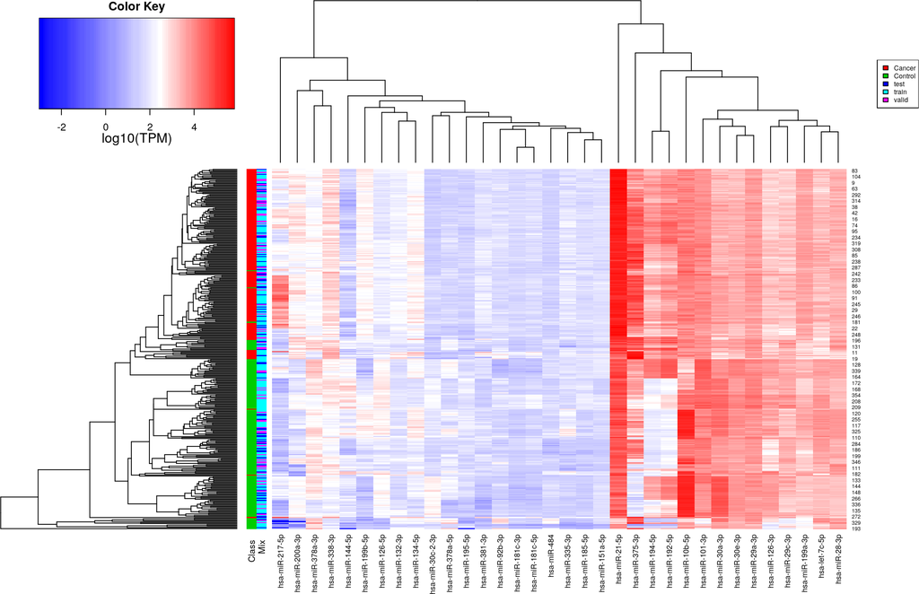

```r
OmicSelector_heatmap(x = dplyr::select(mixed, gsub("\\.", "-", selected_miRNAs)), rlab = data.frame(Class = mixed$Class, Mix = mixed$mix), zscore = F, margins = c(10,
    10))
```

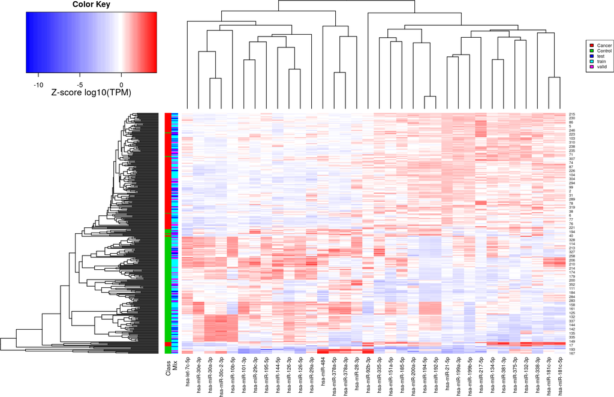

```r
OmicSelector_heatmap(x = dplyr::select(mixed, gsub("\\.", "-", selected_miRNAs)), rlab = data.frame(Class = mixed$Class, Mix = mixed$mix), zscore = T, margins = c(10,
    10))
```

Based on everything we have done so far, we suggest using the following signature in further validation of biomarker study.

```r
cat(paste0(gsub("\\.", "-", selected_miRNAs), collapse = ", "))
```

```
#> hsa-miR-21-5p, hsa-miR-30e-3p, hsa-miR-30a-3p, hsa-miR-30c-2-3p, hsa-miR-132-3p, hsa-miR-375-3p, hsa-miR-217-5p, hsa-miR-338-3p, hsa-miR-199b-5p, hsa-miR-381-3p, hsa-miR-199a-3p, hsa-miR-194-5p, hsa-miR-134-5p, hsa-miR-192-5p, hsa-miR-200a-3p, hsa-miR-181c-3p, hsa-miR-29a-3p, hsa-miR-378a-3p, hsa…
```

# 8 Sesssion

To render this tutorial we used:

```r
render("Tutorial.Rmd", output_file = "Tutorial.html", output_dir = "../static/")
```

Packages installed in our docker enviorment:

```r
OmicSelector_table(as.data.frame(installed.packages()))
```

[output not shown]

[output cut: 720 more lines]